# MONITORING 2025 : PARCOURS D’ACCUEIL ET D’ACCOMPAGNEMENT DES PRIMO-ARRIVANTS ET DES PERSONNES ÉTRANGÈRES

### REMERCIEMENTS

Nous tenons à remercier ici l’ensemble des acteur·rices du parcours d’accueil (Bureau d’accueil, opérateurs de formation linguistique, partenaires) ainsi que l’Administration de la Commission Communautaire Commune (COCOM) et l’Administration de la Commission Communautaire Française (COCOF). C’est grâce à leur disponibilité et leurs explications des réalités de terrain que nous pouvons mieux comprendre ce dispositif.

# 1 INTRODUCTION

## 1.1 Objectifs et structure du rapport

Comme défini par l’Art. 82 de l’Arrêté de 2024 de la COCOM, ce **rapport annuel de monitoring** du dispositif “**Parcours d’accueil et d’accompagnement des primo-arrivants et personnes étrangères”** consiste en une synthèse des données administratives produites par les Bapas. Il vise à faire le suivi de la mise en œuvre concrète du dispositif.

Il se compose de quatre parties. La première consiste en une introduction au contexte territorial, à savoir les contextes migratoire et institutionnel, dans lequel prend place le parcours d’accueil francophone en Région de Bruxelles-Capitale.

Les trois parties suivantes visent à appréhender globalement le fonctionnement du parcours d’accueil. Basées sur des indicateurs quantitatifs standardisés, elles doivent permettre de saisir les évolutions de son fonctionnement au regard des années précédentes. À la demande des pouvoirs publics, nous y distinguons la catégorie des usager·ères et le genre quand cela est pertinent. Ces trois parties s’attachent à des aspects spécifiques du parcours :

- Partie II : l’organisation générale des bureaux d’accueil (stock de dossiers actifs et suspendus, flux d’inscriptions, ressources humaines, etc.).
- Partie III : les publics du parcours d’accueil (profils socio-démographiques) ;
- Partie IV : les actions mises en œuvre par les Bapas (suivies des activités du parcours d’accueil) ;

Nous concluons le rapport en pointant les enjeux et les perspectives auxquelles la politique d’accueil sera amenée à faire face dans les années à venir au regard des chiffres présentés.

## 1.2 Méthodologie : données, démarche et limites

**Sources de données**

Les analyses de ce rapport reposent principalement sur l’exploitation des données de l’application « Acompagnement des Primo-Arrivants » (APA), qui est l’outil employé par les travailleur·euses des Bapas pour gérer les dossiers des usager·ères[^1]. Le CBAI est chargé de produire des données agrégées à partir de cette base de données, de façon à alimenter la rédaction des rapports d’activités des Bapas. Ce rapport se base globalement sur les mêmes données et méthodologies que celles utilisées pour fournir aux Bapas les informations utiles à la rédaction de leurs rapports d’activités (extraction en janvier 2026).

Nous avons complété cette source principale en mobilisant les rapports d’activités des Bapas. Ceux-ci comprennent en effet des données, tant quantitatives (registre de présence) que qualitatives (témoignages de terrain), qui précisent, nuancent et contextualisent les données de l’APA. En particulier, les données qui ont trait à l’offre pour lesquelles les registres de présence des Bapas sont plus précis que l’APA (modules DD et FOCI).

Enfin, les données de la contextualisation territoriale (partie 1) proviennent de l’Institut Bruxellois de Statistique et d’Analyse (IBSA) – tant de leur site web pour les flux de l’immigration que d’une demande de données plus précise pour les effectifs de personnes primo-arrivantes et personnes étrangères –, ainsi que du Commissariat Général aux Réfugiés et aux Apatrides (CGRA) et du Centre fédéral Migration (Myria).

**Démarche**

Concernant la démarche, il faut distinguer deux approches complémentaires de comptabilisation des dossiers des Bapas, et *ipso facto* des usager·ères, des activités et de la charge de travail des bureaux d’accueil, selon :

- une **logique de flux (entrants/sortants)** : nombre total de dossiers inscrits (ou clôturés) dans le Parcours d’accueil sur une durée déterminée (souvent une année) ;
- une **logique de stock** : nombre total de dossiers actifs à une date précise (souvent à la fin ou au début de l’année).

Bien que ce monitoring mobilise les deux approches – les flux pour évaluer l’évolution des publics aux différentes étapes du dispositif et les stocks pour évaluer la charge de travail réelle des Bapas – la législation actuelle détermine le régime de subvention selon une logique de stock (la moyenne des dossiers actifs chaque jour de l’année, peu importe l’année d’inscription de l’usager·ère).

Par ailleurs, dans un souci de refléter au mieux la réalité de cette politique publique, nous avons décidé, en 2025, de revoir la terminologie utilisée pour désigner les personnes concernées par le parcours d’accueil. Depuis 2016, année de mise en place de cette politique, nous utilisons le terme « bénéficiaires du parcours d’accueil », en raison du caractère gratuit et théoriquement volontaire[^2] du dispositif. Toutefois, nous estimons aujourd’hui que cette appellation ne rend plus pleinement compte de sa réalité. En effet, pour une grande partie du public, le parcours d’accueil est désormais obligatoire sous peine de sanction. Nous privilégions dès lors le terme « usager·ères », qui nous paraît davantage en adéquation avec le cadre dans lequel s’inscrit aujourd’hui la majorité des personnes suivant le parcours d’accueil.

**Limites**

Enfin, il convient de souligner que l’APA a connu plusieurs évolutions et modifications au cours des deux dernières années, lesquelles ont provoqué des **problèmes techniques et certains dysfonctionnements**[^3]. Ceux-ci compliquent l’exploitation des données et imposent certains choix méthodologiques, tout en introduisant plusieurs limites largement développés dans les précèdents rapport de monitoring[^4] .

**Rappels méthodologiques**

Avec la saturation du dispositif, **les seuls critères d’admission qui étaient en vigueur en 2024 ne suffisent à garantir l’entrée dans le parcours d’accueil**. Désormais il faut tenir en compte les **capacités disponibles des Bapas à prendre en charge un·e usager·ère**. Dans ce contexte, le statut « *admis* » dans l’APA, qui correspondait auparavant à une admission effective, correspond aujourd’hui aux personnes en attente d’une place. Ce statut permet d’identifier ce public et d’estimer leur ancienneté sur la liste d’attente. Cette évolution peut entraîner des écarts avec les chiffres publiés dans le Monitoring 2023.

Par ailleurs, la définition du dossier actif figurant dans l’Ordonannce n’est plus adaptée à la réalité actuelle du dispositif. Dans le cadre du présent rapport, est considéré comme actif tout dossier qui n’est ni en liste d’attente, ni clôturé, ni suspendu. Une exception est toutefois prévue pour les dossiers suspendus de **primo-arrivant·es bénéficiant d’une prolongation du délai de parcours, lesquels sont intégrés dans ce rapport dans les données relatives aux dossiers actifs.**

# 2 LE CONTEXTE DE MISE EN ŒUVRE DU PARCOURS D’ACCUEIL

## 2.1 Contexte institutionnel : saturation du dispositif

Le parcours d’accueil pour primo-arrivant·es est mis en œuvre par **trois associations agréées par la Cocom**, communément appelées Bureaux d’accueil pour primo-arrivant·es (BAPA); **VIA** et **BAPA-BXL**, actifs depuis 2016, ainsi que **Convivial**, reconnue depuis 2020. Ces opérateurs interviennent sur **cinq implantations**, les activités de VIA et de Convivial étant réparties chacun sur deux sites : VIA opère à Schaerbeek et Molenbeek, tandis que Convivial intervient à Forest et, à Anderlecht. Les trois Bapas bénéficient aujourd’hui d’un agrément de type IV (capacité de traitement de 2.000 dossiers actifs).

Le cadre législatif de la COCOM définit deux catégories de public cible :

1. **Les primo-arrivant·es** (prioritaires et non-exempté·es de l’obligation) : toutes les personnes étrangères majeures de moins de 65 ans, originaires d’un pays hors de l’UE27+ et ne remplissant pas l’une des autres conditions d’exemption[^5], séjournant légalement en Belgique depuis moins de trois ans, et inscrit·es avec un titre de séjour de plus de trois mois au registre national d’une commune de la RBC.
2. **Les personnes étrangères** (non-prioritaires ou exemptées de l’obligation) **:** toute personne étrangère majeure, inscrite au registre des étrangers ou de la population d’une commune du territoire bilingue de la RBC et disposant d’un titre de séjour de plus de trois mois et qui n’est pas obligée de suivre le parcours d’accueil.

En 2025, la **saturation demeure une réalité pour l’ensemble des opérateurs.** Pour rappel, celle-ci résulte principalement des réformes législatives adoptées en 2022[^6]. Les deux Bapas historiques ont atteint leur capacité maximale dès décembre 2023. Convivial, malgré son passage en catégorie IV et l’ouverture d’une seconde implantation, a à son tour atteint un état de saturation en septembre 2024.

Cette saturation se traduit par une augmentation continue du nombre d’usager·ères prioritaires pris·es en charge, au détriment des personnes étrangères non prioritaires, davantage susceptibles d’être inscrites en liste d’attente.

L’année 2025 a également été marquée par plusieurs difficultés opérationnelles liées à des dysfonctionnements techniques de l’APA. D’importantes mises à jour informatiques ont été réalisées, notamment en matière de sécurité, de logiciel et de corrections de bugs qui ont impacté la stabilité et le bon fonctionnement quotidien de l’outil de gestion des Bapas, plaçant parfois les travailleur·euses en difficulté[^7].

Enfin, le Code la nationalité a fait l’objet d’une modification en juin 2025, portant à 1.000 euros (indexable) le droit d’enregistrement pour toute demande de nationalité belge. Cette hausse significative est susceptible d’avoir un impact sur le recours au parcours d’accueil par certaines personnes étrangères non-prioritaires, notamment lorsque celui-ci est envisagé dans une perspective d’accès ultérieur à la nationalité belge. A ce stade, aucun impact quantitatif n’est encore observable sur les flux. Toutefois, les Bapas ont signalé une augmentation du niveau de stress parmi certains publics, lesquels cherchaient à accélérer leur entrée dans le parcours avant l’augmentation des frais liés aux démarches de nationalité, alors que le dispositif était déjà saturé.

## 2.2 Contexte territorial : immigration, séjours et publics cibles

La parcours d’accueil bicommunautaire pour primo-arrivant·es (Cocom) est mis en œuvre sur le territoire de la Région de Bruxelles-Capitale (RBC). Toutefois, certaines données contextuelles ne sont disponibles qu’à l’échelle nationale[^8], comme les données relatives aux titres de séjour et aux demandes de protection internationale. Les données sur les flux d’immigration internationale et les personnes étrangères, dont les primo-arrivantes, concernent quant à elles la RBC.

### 2.2.1 L’immigration internationale en RBC

En 2025, les dynamiques observées les années précédentes demeurent globalement stables, les personnes étrangères en RBC représentent 37 % de la population régionale. Cette proportion est largement supérieure aux deux autres régions belges (11 % chacune)[^9]. De même, la part des personnes en RBC nées à l’étranger atteint 61 %, contre 22 % en Wallonie et 20 % en Flandre. Parmi ces personnes nées à l’étranger, 59 % ont des nationalités hors de la zone UE-27 en RBC et en Flandre, contre 45 % en Wallonie. Cette part ne cesse d’augmenter depuis les 20 dernières années et montre ainsi la diversification de l’immigration tant en termes de nationalités que de motifs (cf. Infra : titre de séjours). Notons que la nationalité française est la première nationalité étrangère depuis 2005 en RBC et représente environ 5,7% de la population totale de la Région bruxelloise au 1er janvier 2025 (71.597 personnes). Suivent ensuite les Roumain·es (3,7%), les Italien·nes (2,9%) puis les Espagnol·es et Marocain·es (2,6% chacun·e).

La population étrangère récemment arrivée à Bruxelles est importante. En moyenne, au cours des cinq dernières années (2020-24), la Région a accueilli chaque année environ 49.000 personnes en provenance de l’étranger.

Si l’immigration ukrainienne continue de reculer en 2024 (le groupe « Reste de l’Europe » diminue de 11% par rapport à 2023), le flux total des premières entrées reste supérieur aux années 2011 (50.455 immigrants), tout en se rapprochant des niveaux observés en 2019. Du point de vue des (autres) nationalités, bien que les ressortissant·es des nouveaux États membres de l’UE continuent de diminuer (-9%), les pays de l’UE27 représentent toujours plus de la moitié des premières entrées (55%). On notera une augmentation relativement significative de personne issues de Turquie (+18%).

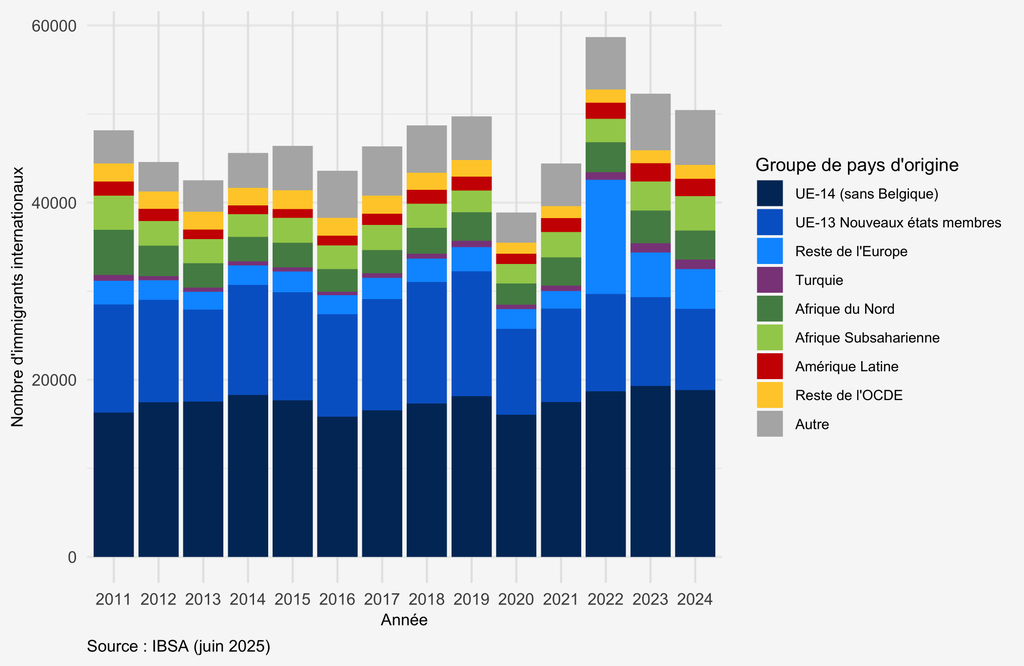

Figure 1: Évolution de l’immigration internationale en RBC (2011-2024).

### 2.2.2 Les premiers titres de séjour en Belgique

Les dernières données disponibles de Myria sur les titres de séjour portent sur l’année 2023. Cette année-là, 139.052 premiers titres de séjour[^10] ont été délivrés, soit une diminution après une année 2022 marquée par un niveau exceptionnellement élevé depuis 2010. Cette baisse s’explique principalement par la diminution des arrivées liées à la guerre entre l’Ukraine et la Fédération de Russie. Le nombre de premiers titres délivrés à des ressortissant·es ukrainien·nes a ainsi chuté de 71% par rapport à 2022, tout en restant une part importante, majoritairement dans le cadre de la protection temporaire. Ainsi, pour la deuxième années consécutive, **une part plus importante (56%) des premiers titres de séjour a été délivrée à des ressortissants·es de pays tiers**, soit 78.380 pour 60.672 pour les citoyen·nes européen·nes.

Concernant les motifs de séjour en 2023, parmi les citoyen·nes de l’UE, la moitié des premiers titres est délivrée pour des raisons liées à une activité rémunérée (50% - et 57% en y ajoutant les études). Tandis que pour les ressortissant·es de pays tiers, ce sont les raisons familiales les plus fréquentes (31%), suivis de la protection temporaire (19%), la protection internationale (13%), des études (12%), et des activités économiques (11%). Notons que les premiers titres de séjour liés à la protection internationale augmentent de 30% et les raisons humanitaires ou médicale progressent de 88%. Les autres catégories de motifs demeurent globalement assez stables.

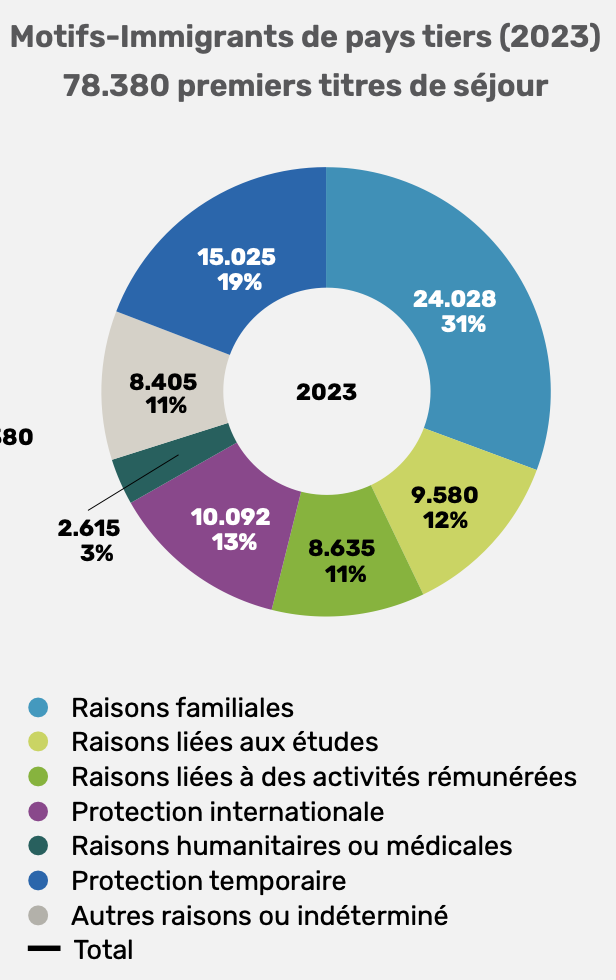

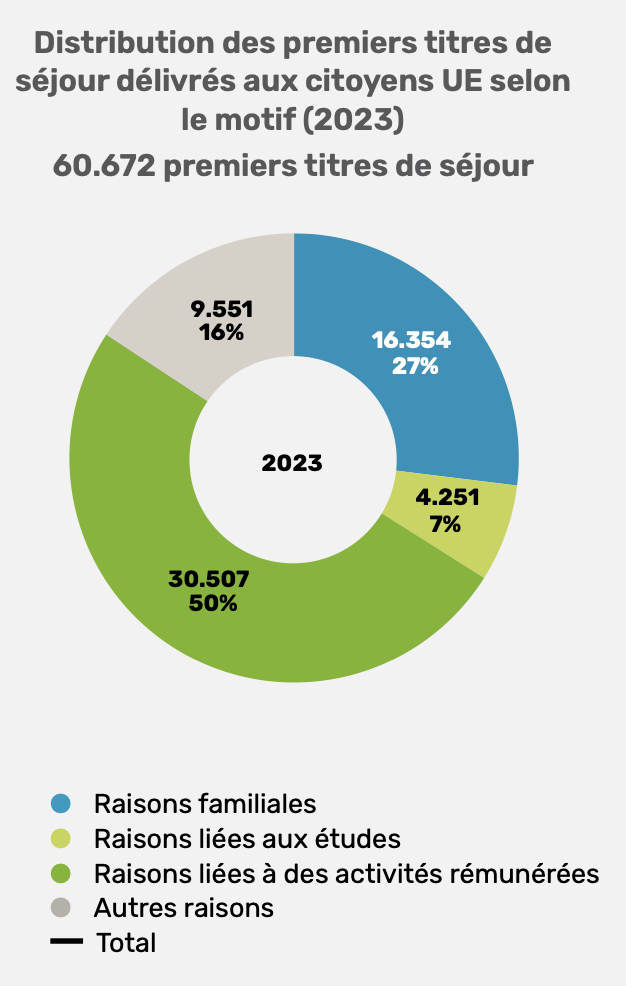

Figure 2: Motifs des délivrance des premiers titres de séjour. Source : Myria (2025)

Concernant les protections internationales (Figure 3), des chiffres plus récents ont été publiés par le CGRA. En 2025, 34.439 demandes de protection internationale ont été enregistrées en Belgique, soit une diminution de 13% par rapport à 2024. Cette baisse concerne principalement les premières demandes (-16% par rapport à 2024) et atteignent leur niveau le plus faible depuis 2022. A l’inverse, le nombre de demandes ultérieures augmente de 6% par rapport à 2024 et représentant désormais 20% de l’ensemble des demandes.

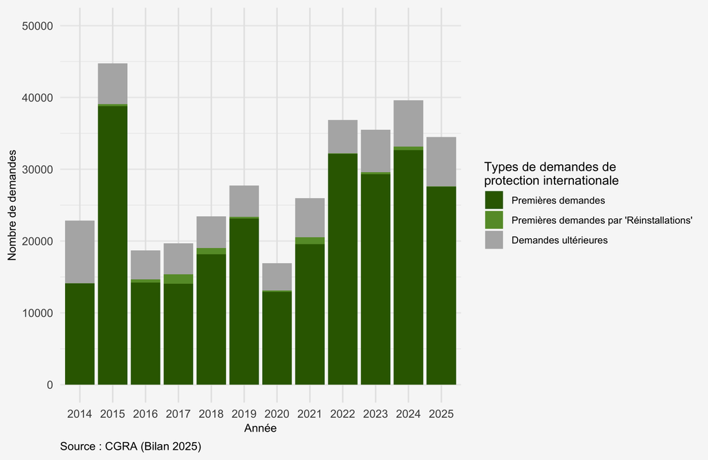

Figure 3: Évolution du nombre de premières demandes de protection internationale (2014-2025).

L’année 2025 est également marquée par des évolutions parmi les principales nationalités à l’origine des premières demandes de protections. Les demandes introduites par des ressortissant·es syrien·nes diminuent fortement, avec environ 4.000 (premières) demandes de moins qu’en 2024 (-11pp). Cette évolution s’inscrit dans le contexte de la chute du régime de Bachar Al Assad en décembre 2024[^11].

Par ailleurs, parmi les dix principales nationalités, une augmentation du nombre de premières demandes est observées pour les ressortissant·es d’Érythrée (en 2e position + 11%), de la République démocratique du Congo (+19%), d’Afghanistan (+28%) et du Burundi (+32%) par rapport à 2024.

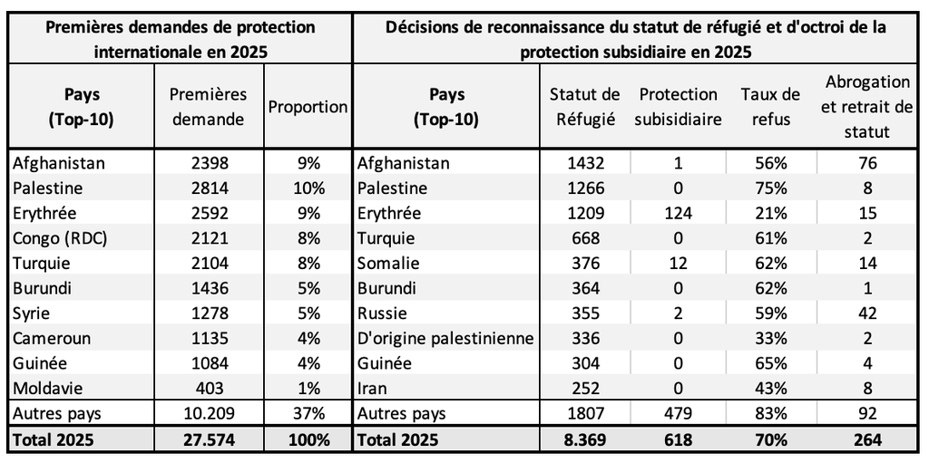

Les premières demandes de Protection internationale et les décisions de reconnaissance selon les dix premières nationalités. Source : CGRA (Bilan 2025)

En 2025, le CGRA a pris 25.920 décisions concernant 31.457 personnes. Le taux de protection atteint son niveau le plus faible depuis plus d’une décennie[^12]. **Le classement des nationalités bénéficiant le plus souvent d’une reconnaissance du statut de réfugié ou d’une protection subsidiaire diffère de celui des premières demandes de protection internationale** *(tableau ci-dessus).* Deux éléments permettent d’expliquer cet écart. D’une part, il existe un décalage temporel parfois important entre l’introduction d’une demande et la décision finale. D’autre part, le taux de refus varie selon les nationalités*.*

**Le taux de refus atteint 70%** toutes nationalités confondues, soit son **niveau le plus élevé au cours des dix dernières années** (Figure 4). Certaines nationalités présentent des taux de refus particulièrement élevés. C’est notamment le cas des Palestinien·nes (75%; 71% si l’on inclut les personnes d’origines palestinienne), tandis que les taux observés pour les Erythréen·nes (21%) ou les Iranien·nes (43%) demeures inférieurs. Cette hause du taux de refus s’explique principalement par deux décisions politiques récentes :

**En premier lieu, le gel du traitement en 2025 des demandes introduites par des personnes ayant fui la Syrie,** dont le dossiers débouchaient auparavant fréquemment sur une décision positive. **En deuxième lieu,** l’adoption en juillet 2025 de **la loi limitant l’accueil des demandeur·euses de protection internationale déjà protégés dans un autre Etat membre de l’UE**[^13] en Belgique[^14] et qui ont conduit à un traitement prioritaire de ces dossiers et à une augmentation des décisions d’irrecevabilité (+36%).

Parallèlement, le CGRA a lancé une opération visant à résorber l’arriéré des dossiers nécessitant une réévaluation du statut de protection pour des raisons d’ordre public. Cette action a conduit à une augmentation importante des retraits et d’abrogations de statut. Ainsi, le statut de protection a été retiré à 171 personnes (contre 48 en 2024) et abrogé pour 93 personnes (contre 28 en 2024).

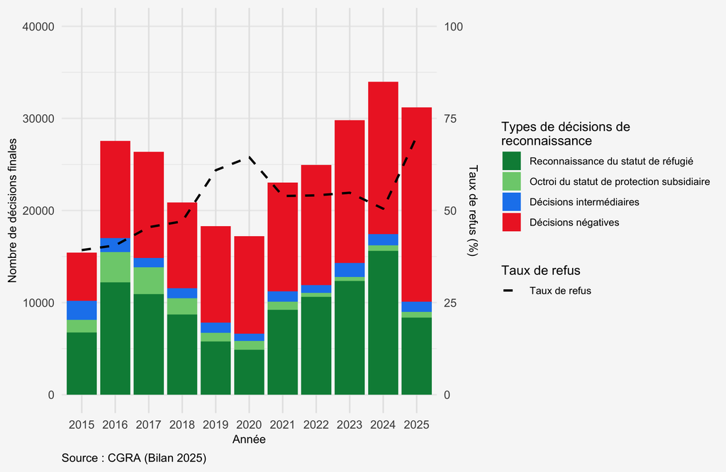

Figure 4: Évolution du nombre de types de décisions (2015-2025).

### 2.2.3 Les publics ciblés par le Parcours d’accueil

Après avoir exposé les flux de l’immigration en RBC et les reconnaissances et motifs de séjour en Belgique, nous présentons dans ce deuxième sous-point la géographie (résidentielle) des deux publics cibles du Parcours d’accueil : les personnes primo-arrivantes (2.2.3.1 et les « personnes étrangères » (2.2.3.2).

Pour rappel, le poids démographique de ces publics ciblés par le Parcours d’accueil est proportionnellement plus important en RBC que dans les deux autres régions — *grosso modo* un rapport de trois. Ce rapport s’observe autant de façon agrégée, c’est-à-dire sur l’ensemble des personnes étrangères, qu’au niveau des sous-catégories de personnes étrangères relatives à leur durée de séjour (plus ou moins de trois ans).

#### 2.2.3.1 Les primo-arrivant·es en RBC

Dans cette partie, nous présentons le **stock** de personnes primo-arrivantes (PA), qu’elles soient prioritaires ou non, au **1er janvier 2025**, par commune et à l’échelle des secteurs statistiques (Table 1*)*. Nous distinguons les PA originaires de l’UE27- exempté·es de l’obligation de suivi, et par conséquent non-prioritaires — de celles et ceux issu·es de pays tiers (hors UE27+) — c’est-à-dire **potentiellement soumis·es à l’obligation** (sans autres motifs d’exemption)*.* Ces chiffres ne prétendent donc pas donner un volume exhaustif des personnes effectivement concernées par l’obligation, mais plutôt donner une indication de la structure spatiale de leur répartition en RBC.

| Communes | Primo-arrivant·es (total) Effectif | Primo-arrivant·es (total) Part du total de PA de la région (%) | Primo-arrivant·es (total) Part cumulée | Primo-arrivant·es hors-UE27+ Effectif | Primo-arrivant·es hors-UE27+ Part du total de PA de la commune (%) | Primo-arrivant·es hors-UE27+ Quotien de localisation (spécificité régionale) |
| --- | --- | --- | --- | --- | --- | --- |
| Bruxelles | 21061 | 20,5 | 20,5 | 9701 | 46,1 | 0,98 |
| Ixelles | 13837 | 13,5 | 34,0 | 4477 | 32,4 | 0,69 |
| Schaerbeek | 9143 | 8,9 | 42,9 | 4386 | 48,0 | 1,02 |
| Anderlecht | 8209 | 8,0 | 50,9 | 4891 | 59,6 | 1,27 |
| Etterbeek | 6609 | 6,4 | 57,4 | 2269 | 34,3 | 0,73 |
| Saint-Gilles | 5969 | 5,8 | 63,2 | 2146 | 36,0 | 0,77 |
| Uccle | 5094 | 5,0 | 68,1 | 2069 | 40,6 | 0,87 |
| Woluwe-Saint-Lambert | 4999 | 4,9 | 73,0 | 2552 | 51,1 | 1,09 |
| Molenbeek-Saint-Jean | 4625 | 4,5 | 77,5 | 3323 | 71,8 | 1,53 |
| Forest | 3494 | 3,4 | 80,9 | 1564 | 44,8 | 0,95 |
| Saint-Josse-ten-Noode | 3488 | 3,4 | 84,3 | 1525 | 43,7 | 0,93 |
| Evere | 3141 | 3,1 | 87,4 | 2133 | 67,9 | 1,45 |
| Jette | 3126 | 3,0 | 90,4 | 1875 | 60,0 | 1,28 |
| Woluwe-Saint-Pierre | 2749 | 2,7 | 93,1 | 1285 | 46,7 | 1,00 |
| Auderghem | 2383 | 2,3 | 95,4 | 1276 | 53,5 | 1,14 |
| Koekelberg | 1650 | 1,6 | 97,0 | 969 | 58,7 | 1,25 |
| Ganshoren | 1169 | 1,1 | 98,2 | 679 | 58,1 | 1,24 |
| Berchem-Sainte-Agathe | 998 | 1,0 | 99,2 | 601 | 60,2 | 1,28 |
| Watermael-Boitsfort | 861 | 0,8 | 100,0 | 442 | 51,3 | 1,09 |
| Région de Bruxelles-Capitale | 102605 | 100,0 | 100,0 | 48163 | 46,9 | 1,00 |

Source : IBSA & Statbel (Direction générale Statistique – Statistics Belgium) (Registre national) (janvier 2025)

Table 1: Répartition des personnes primo-arrivantes selon les communes de résidence

On constate premièrement que **quatre communes concentrent à elles seules la moitié (51%) des personnes primo-arrivantes** : la Ville de Bruxelles (20,5%), Ixelles (13,5%), Schaerbeek (9%), Anderlecht (8%). Ces proportions sont très similaires à celles de l’année dernière, à l’exception d’une augmentation de 8% à Anderlecht. Toutefois, si l’on s’intéresse non pas aux effectifs absolus mais au degré de spécialisation (quotient de localisation[^15]) des personnes primo-arrivantes « potentiellement prioritaires » (hors EU27+), ce classement communal est différent : Molenbeek (1,53), Evere (1,45), Berchem-Sainte-Agathe (1,28), Jette (1,28), Anderlecht (1,27) et Koekelberg (1,25), etc. On note encore que les communes de la première couronne sud-est — telles qu’Etterbeek, Ixelles et Saint-Gilles — comptent des effectifs importants de primo-arrivant·es, mais sont nettement moins spécifiques aux ressortissant·es de pays tiers.

Ces constats apparaissent plus nettement encore à l’échelle **infracommunale** (Figure 5). Si les primo-arrivant·es sont nombreux·euses (en effectif absolu) dans les *quartiers sud et sud-es*t de la première couronne, les personnes primo-arrivantes extra-européennes y sont nettement moins représentées (en part relative) qu’à l’ouest et au nord de la Région. Certains quartiers de la deuxième couronne méritent une attention particulière :

- **Evere**, où l’on observe une présence marquée de la communauté indienne[^16] ;
- **Ixelles**, avec une concentration d’étudiant·es étranger·ères dans les quartiers universitaires (ULB-VUB), et qui sont souvent exempté·es de l’obligation ;
- ainsi que quelques **quartiers « diplomatiques »** spécifiques du sud-est de la RBC (Uccle, Woluwe-Saint-Pierre), où résident des fonctionnaires de missions étrangères (comme les ambassades de Russie ou de Chine), et dont le personnel est également exempté·es.

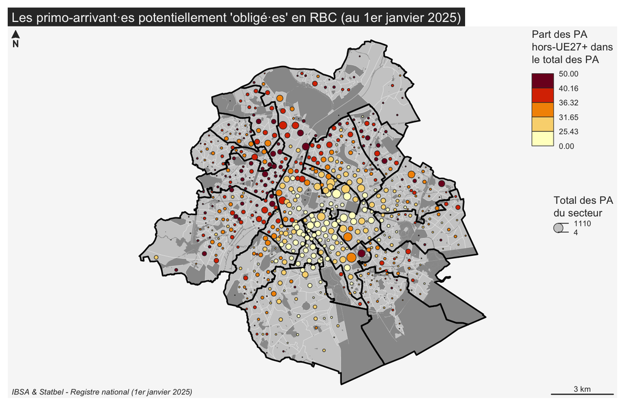

Figure 5: Géographie résidentielle des personnes primo-arrivantes au 1er janvier 2025

#### 2.2.3.2 Les personnes étrangères en RBC

La géographie résidentielle des personnes étrangères titulaires d’un titre de séjour de plus de trois ans rejoint celle des primo-arrivant·es. On y retrouve notamment le **clivage nord-ouest / sud-est** dans **la spécialisation des quartiers pour les ressortissant·es hors UE27+.** Toutefois, les quartiers du nord-ouest, et y compris ceux de la deuxième couronne, affichent des effectifs (absolus) nettement plus élevés de ressortissant·es de pays tiers que ceux observés pour les primo-arrivant·es. Ce constat peut être mis en perspective avec les dynamiques résidentielles à l’œuvre dans la Région, notamment des personnes issues de l’immigration internationale, déjà documentées par ailleurs[^17].

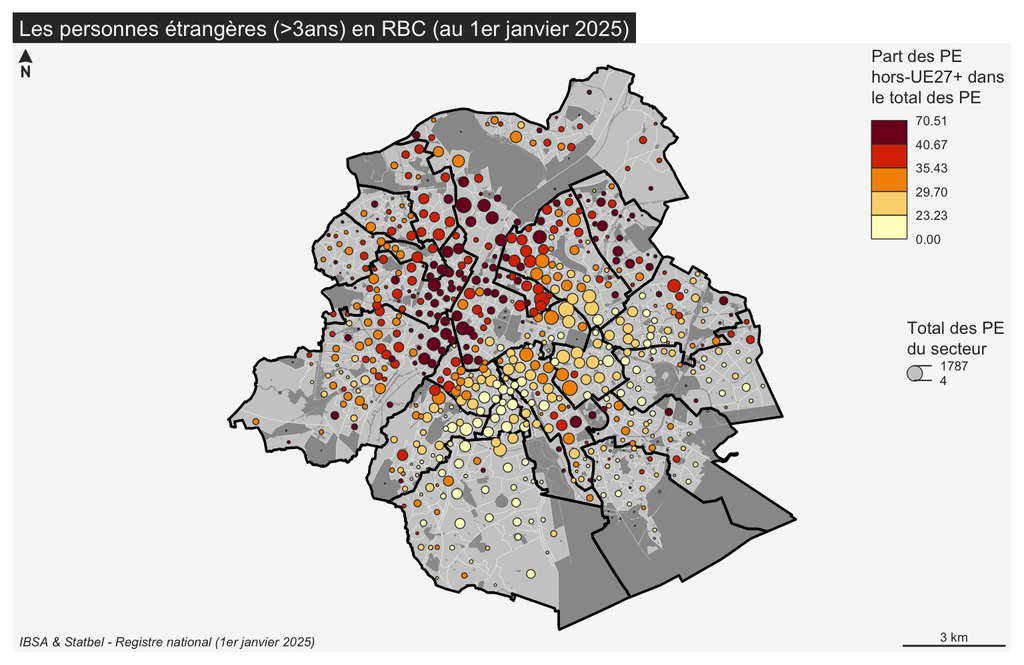

Figure 6: Géographie résidentielle des personnes étrangères (>3ans) au 1er janvier 2025

# 3 ORGANISATION DU DISPOSTIF

Nous présentons ici l’état actuel du dispositif, d’abord dans une logique de flux, puis dans une logique de stock, avant de rendre compte de la charge de travail réelle des Bapas au regard des ressources humaines disponibles.

**Rappel : deux logiques complémentaires**

- Les **dossiers inscrits au cours d’une période donnée** dans le Parcours, en l’occurrence l’année 2025, c’est-à-dire la logique de flux
- Les **dossiers actifs à une date précise dans le Parcours**, en l’occurrence le 31 décembre 2025, c’est-à-dire la logique de stock. Celle-ci permet de mettre en évidence le report de charge annuelle (dossiers inscrits avant 2025 et toujours actifs à cette date).

## 3.1 L’évolution du flux d’inscription

Entre 2022 et 2023, le nombre d’inscriptions dans le parcours d’accueil a triplé, atteignant un nombre record d’inscrits passant d’environ 500 à 1.500 par trimestre. A partir de 2024, le flux trimestriel se « stabilise », voire il ralentit, autour des 1.000 et 1.200 inscriptions, sous l’effet de l’instauration des premières listes d’attentes qui limite les entrées, jusqu’à l’arrivée progressive à une saturation globale du dispositif, réduisant la capacité d’inscription.

Le dispositif n’absorbe désormais plus l’ensemble de la demande entrante, mais opère une sélection des inscriptions en fonction du caractère prioritaire des dossiers, conformément au cadre législatif en vigueur. Dans ce contexte, le nombre de nouvelles inscriptions diminue tandis que le volume de personnes inscrites sur liste d’attente continue d’augmenter. En 2025, le nombre de nouvelles inscriptions recule à nouveau de 4%, confirmant cette tendance. Au total **5.167 nouvelles personnes ont été inscrites dans le parcours au cours de l’année** (Figure 7). Toutefois, ce volume demeure supérieur à deux fois la moyenne annuelle observée avant la pandémie et avant les réformes de 2022 (période 2017-2019). Les niveaux d’inscription annuels atteints de nos jours semblent constituer le **nouveau standard post-réformes du dispositif**. Plus largement, **55% de l’ensemble des inscriptions enregistrées depuis la création du parcours d’accueil ont eu lieu au cours des trois dernières années.**

Au-delà des nouvelles inscriptions l’on retrouve aussi des **dossiers réactivés** (en pointillés dans le graphique ci-dessous). Un dossier réactivé correspond à un dossier qui a été archivé dans l’APA sans que le parcours ait été réalisé[^18] et qui redevient actif ultérieurement. Il s’agit majoritairement d’ancien·nes participant·es de la période pré-obligation (2019-2021), revenant pour finaliser le parcours. Si la réactivation de dossiers a toujours existé dans le parcours d’accueil, leur poids n’a jamais été si important qu’au cours des deux dernières années. Bien que généralement moins lourds à traiter, une partie du parcours est souvent déjà réalisé (bilans, droits et devoirs, voire formations citoyennes), ces dossiers restent significatifs et permettent de relativiser la diminution du flux des inscriptions.

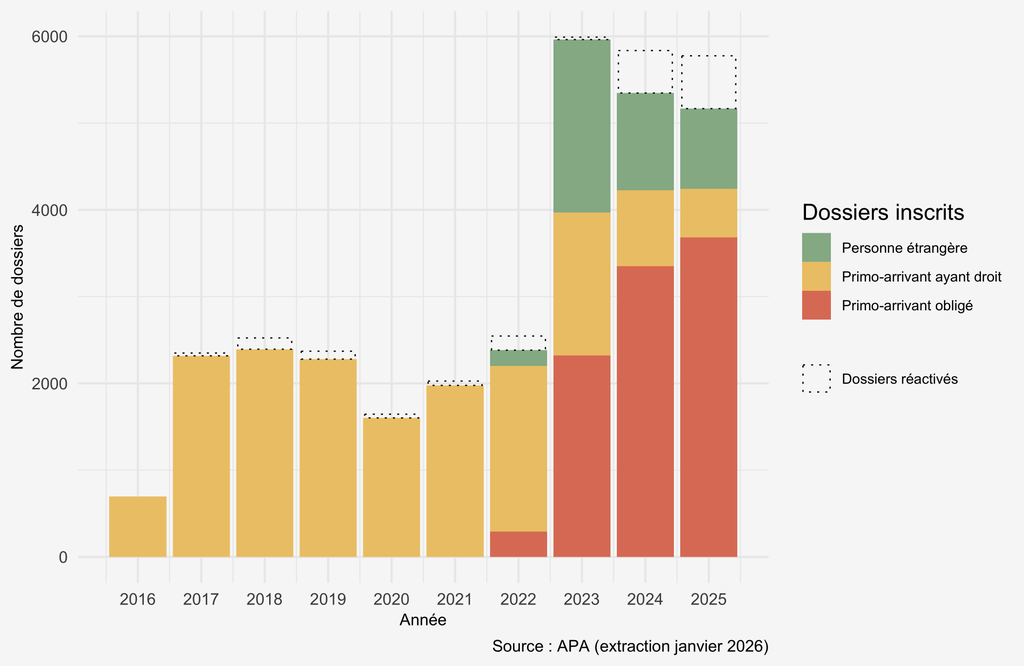

Figure 7: Évolution annuelle du flux d’inscription selon la catégorie d’usager·ères

Depuis 2022, **la part de nouveaux primo-arrivant·es obligé·es inscrit·es dans le parcours d’accueil n’a cessé d’augmenter.** L’année 2025 marque un léger ralentissement mais atteint un taux record de 71% d’inscriptions du public prioritaire. La baisse de la part d’inscriptions des publics non-prioritaires[^19] ne s’explique pas par une diminution de la demande, mais par leur exclusion temporaire, qui concerne plus de la moitié de ces publics (58%[^20]).

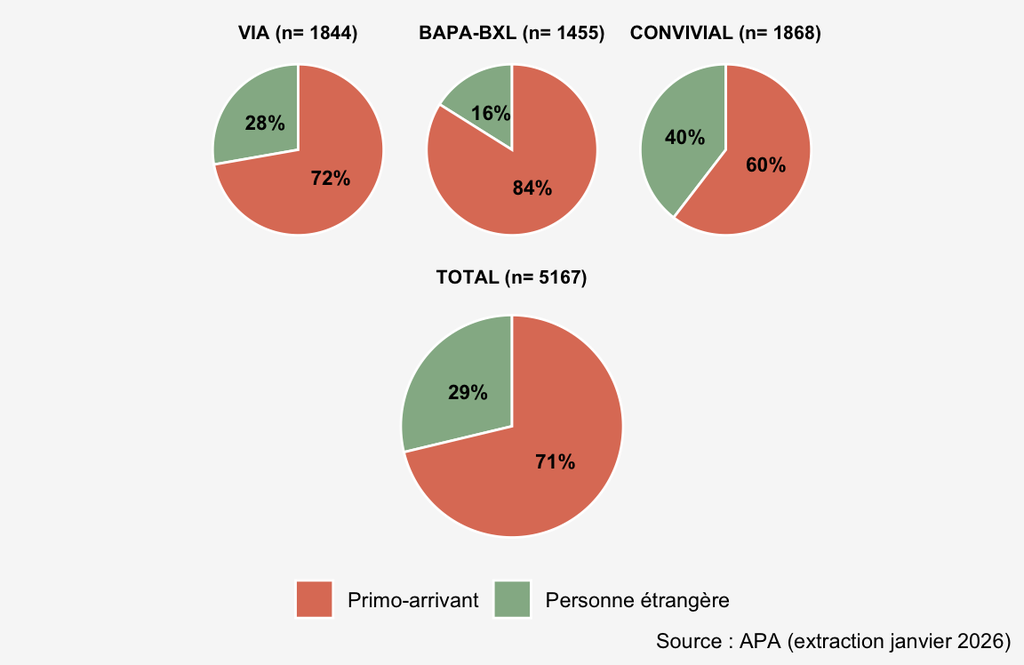

Figure 8: Répartition des nouvelles inscriptions en 2025 selon la catégorie d’usager·ères et l’opérateur

## 3.2 L’évolution du stock de dossiers actifs

L’indicateur le plus pertinent pour évaluer la charge de travail réel des Bapas est celui relatif aux dossiers actifs, ces derniers donnant une mesure du stock d’usager·ères dans le parcours, quel que soit l’année d’inscription et l’étape du parcours dans laquelle se trouve l’usager·ère.

En 2025, les Bapas géraient en **moyenne 5.900 dossiers actifs par jour.** Nous parlons de saturation même si ce chiffre reste en-deçà de la capacité maximale (6.000), car au-delà des dossiers actifs, les dossiers suspendus et ceux en liste d’attente constituent une charge de travail administrative non financée et susceptible de s’activer à tout moment.

Le graphique de l’évolution mensuelle du nombre moyen de dossiers actifs (Figure 9) montre en effet qu’après une **réduction massive des dossiers actifs en 2022** (nettoyage des dossiers « inactifs » en vue de l’augmentation attendue des recours avec les réformes législatives), ces derniers ont fortement augmenté depuis le début de l’année 2023. On observe ensuite **un léger ralentissement à la fin de l’année 2023**, en raison de la saturation du dispositif, l’accroissement du stock de dossiers actifs reprend dès le début de l’année 2024 avec le passage en catégorie IV du BAPA Convivial (+ 500 places/dossiers). Le dispositif connaît une **saturation globale depuis septembre 2024**.

L’année 2025 se caractérise quant à elle par des fluctuations plus marquées du nombre moyen de dossiers actifs. Celles-ci s’expliquent à la fois par des **facteurs structurels**, tels que l’important nombre de dossiers suspendus, et par des **facteurs conjoncturels**, notamment les disparités entre Bapas liées à des sous-effectifs de personnel qui peuvent avoir lieu de manière ponctuelle (absences pour maladie, congés maternité, délai de remplacement longs), l’octroi (ou pas) de financement complémentaires ou encore des difficultés sur le terrain avec la plateforme APA (bugs à l’inscription ou lors des suspensions).

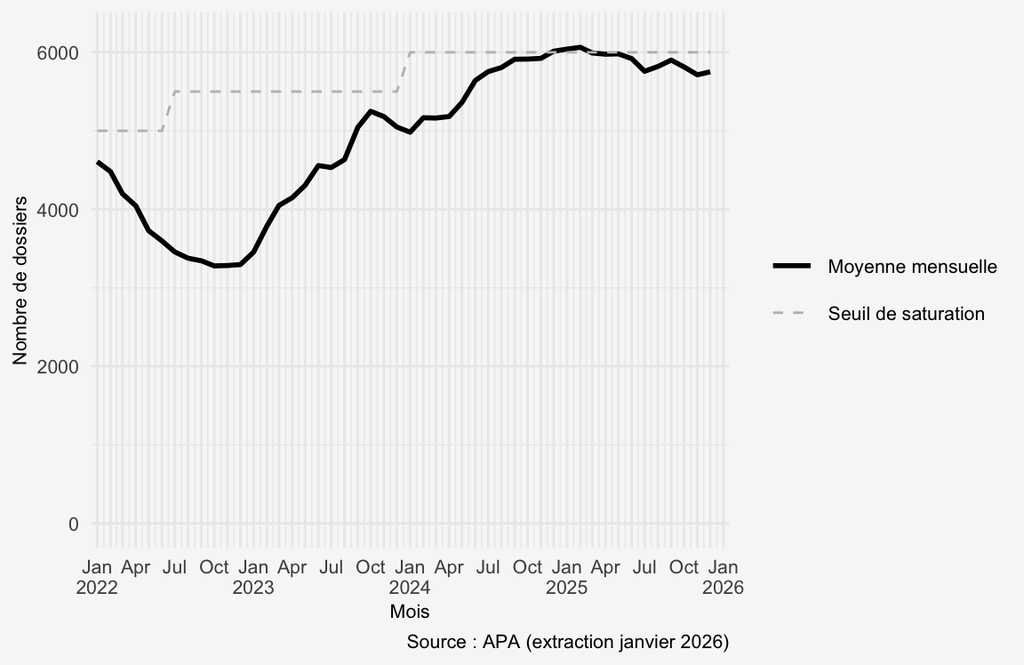

Figure 9: Évolution mensuelle du stock moyen de dossiers actifs par jour

En effet, des **différences existent entre Bapas** : en moyenne VIA gérait quotidiennement 2.136 dossiers actifs (36% du total), Convivial 1923 (33%) et BAPA-BXL 1841 (31%). Ces écarts peuvent ainsi notamment être liés à l’existence de financements complémentaires, permettant de soutenir certaines composantes du Parcours d’accueil insuffisamment subventionnées par l’arrêté d’exécution (notamment en matière de formations citoyenne).

**En décembre 2025, les usager·ères prioritaires représentent environ trois quarts du stock de dossiers actifs.** Alors que, depuis les réformes de 2022, chaque opérateur présentait des spécificités relativement marquées dans la composition de son public, ces différences tendent aujourd’hui à s’atténuer. Cette évolution s’explique par l’augmentation de la part des publics prioritaires, au détriment des non-prioritaires. Le BAPA-BXL concentre la plus forte proportion de primo-arrivant·es, devenant presque exclusivement dédié à ce public (92%), suivi du Bapa VIA avec 73% primo-arrivant·es obligé·es. Toutefois, au Bapa Convivial, les personnes étrangères représentent encore un tiers des dossiers actifs. Cette différence s’explique par une saturation plus tardive que celle des deux Bapas historiques, ce qui leur a permis de maintenir, en 2025, une capacité d’inscription et d’accompagnement des personnes étrangères, bien que plus limitée que lors des années précédentes.

## 3.3 Situation générale : un dispositif saturé

Le dispositif connait pour la première fois en septembre 2024 **une saturation généralisée** qui s’étend jusqu’à aujourd’hui. Au **31 décembre 2025, 1.788 personnes non-prioritaires figurent sur la liste d’attente**, soit plus du **double** par rapport à 2024 (+116%).

Cette situation peut être illustrée par deux indicateurs :

- Le **taux de surpopulation**[^21] s’élève, au 31 décembre 2025, à **125%**, signifiant qu’un quart de la demande est insatisfaite faute de places.
- Le **taux d’exclusion du public non-prioritaire**[^22] — étant donné que seul ce public est à ce jour victime de cette saturation (et peut être placé sur liste d’attente) — s’élève à **58%** en 2025.

Le graphique synthétique suivant (Figure 10) met en perspective l’évolution du stock de dossiers actifs avec ceux des dossiers suspendus et de la liste d’attente au 31 décembre 2025, ainsi que le solde entre les flux entrants (inscription) et sortants (parcours réalisés).

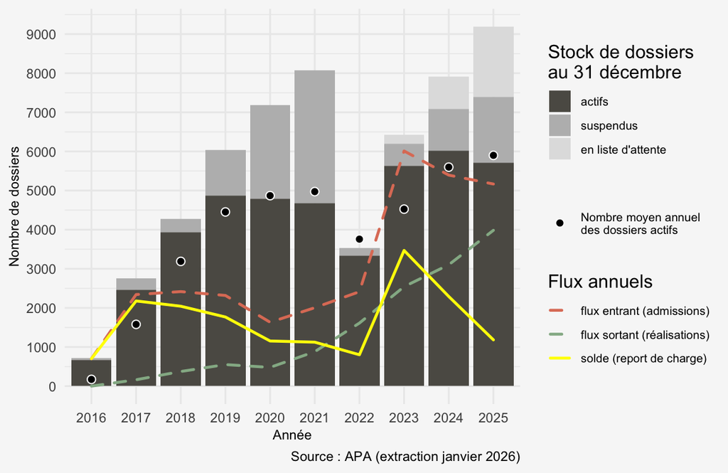

Figure 10: Évolution annuelle du stock des dossiers au 31 décembre (selon l’évolution des flux entrants et sortants)

Deux enseignements peuvent en être tirées :

**Premièrement**, si le nombre de dossiers actifs au 31/12 diminue légèrement par rapport à l’année dernière (-4%), **les dossiers suspendus poursuivent leur progression (+57%)** et **la liste d’attente double (116%)**. La moyenne quotidienne de dossier actif atteint son niveau maximal. Au 31 décembre 2025, on dénombre 5.719 dossiers actifs, **7.423 dossiers potentiellement actifs** (actifs et suspendus). En incluant les personnes en liste d’attente, ce volume atteint 9.211 dossiers, soit une augmentation de 16% par rapport à l’année précédente. La charge des dossiers non actifs augmente substantiellement.

**Deuxièmement**, le solde entre les flux entrants (dossiers inscrits) et sortants (réalisation) diminue continuellement depuis 2023 (-66%)**.** Cette évolution résulte à la fois de la mise en place de la liste d’attente, qui limite le rythme des entrées, et du renforcement progressif de l’offre de formations citoyennes. Malgré cette amélioration, **le report de charge demeure important (+ 1.183 dossiers).** **Le nombre d’entrées continue d’excéder celui des sorties ce qui ne permet pas, à ce stade, de résorber significativement la liste d’attente ni de réduire durablement la pression sur le dispositif. Si cette cadence perdure, le dispositif pourrait bientôt devenir saturé d’obligés.**

Le ratio entre les flux sortants (réalisations) et entrants (inscription) continue de s’améliorer en 2025*,* **les sorties représentent 77% des inscriptions de la même année** (contre 58% en 2024 et 42% en 2023). Toutefois, il varie selon les catégories d’usager·ères (Table 2).

Les **personnes étrangères** **présentent un ratio de sorties supérieures aux entrées** (136%), ce qui signifie que pour 100 inscriptions, environ 136 parcours sont finalisés, contribuant ainsi à la réduction du stock. En raison de la mise en place de la liste d’attente, mais aussi de parcours plus rapide des personnes étrangères pour la part qui recourt au parcours d’accueil dans le cadre de la demande de nationalité. Trois quart (75%) d’entre elleux ont en effet le niveau linguistique requis, ce qui accélère fortement la durée de parcours (cf. infra : chapitre 4).

Si l’on tient compte également des sorties sans réalisation le ratio devient équilibré (102). Cependant, ces sorties n’assurent pas une sorties définitive du parcours mais permettent de libérer temporairement des places de parcours pour inscrire ou réactiver des dossiers.

|  | Entrées | Sorties par réalisation | Sorties par abandon | SORTIES TOTALES | Solde réalisation | Ratio réalisation (%)<sup>1</sup> | SOLDE TOTAL (réalisations + abandons) | RATIO TOTAL (réalisations + abandons) (%)<sup>1</sup> |
| --- | --- | --- | --- | --- | --- | --- | --- | --- |
| Personne étrangère | 1 485 | 2 018 | 1 020 | 3 038 | −533 | 136 | −1 553 | 205 |
| Primo-arrivant | 3 682 | 1 965 | 257 | 2 222 | 1 717 | 53 | 1 460 | 60 |
| Total | 5 167 | 3 983 | 1 277 | 5 260 | 1 184 | 77 | −93 | 102 |

<sup>1</sup> Le ratio des réalisations sur les inscriptions (100% = équilibre des flux entrants et sortants)

Table 2: Tableau synthétique des flux entrants et sortant en 2025 selon les catégories de public.

## 3.4 Ressources humaines et charge de travail

La saturation continue d’exercer une pression sur les Bureaux d’accueil et leurs équipes :

- Au niveau de l’accompagnement social nous pouvons estimer un nombre de **127 dossiers actifs par ETP de travailleur·euses sociaux·ales** en 2025. En y ajoutant les dossiers suspendus, ce chiffre atteint 165 dossiers potentiellement actifs par ETP, une augmentation de 18% par rapport à 2024.
- Au niveau des formations à la citoyenneté, environ **505 heures de FOCI par formateur·trice** ont été données en 2025. Ce qui représente par formateur·trice 8,4 FOCI de 60h par an ou 10 FOCI de 50h[^23].

Si ces chiffres donnent une indication de la charge de travail des formateur·trices à la citoyenneté et des accompagnateur·trices sociaux·ales la plus visible, ils ne reflètent qu’une partie de la charge globale d’un Bapa. Comme souligné les années précédentes, les tâches administratives et organisationnelles se sont renforcées à partir des réforme 2022 et demeurent importantes[^24]. La fin de ce chapitre revient sur cette **inflation de la charge administrative** à partir des rapports d’activités 2025 des trois bureaux d’accueil.

Nous abordons également trois formes moins visibles de la charge de travail : la **pression à l’accueil des Bapas,** et plus spécifiquement la charge des **dossiers placés en liste d’attente**[^25] et troisièmement, la charge latente liée aux **dossiers suspendus** (réactivables à tout moment).

### 3.4.1 L’accueil : un screening du public non-prioritaire

Il convient tout d’abord de mettre en lumière le travail réalisé à l’accueil par les Bapas. Bien que cette activité ne soit pas quantifiée dans l’outil APA, les opérateurs tiennent néanmoins des registres d’accueil qui permettent d’en mesurer partiellement l’ampleur. En 2025, environ **9.650 personnes**[^26] **ont été reçues dans les locaux** des Bapas. Parmi elles, une partie a été inscrite dans le parcours d’accueil au cours de l’année, tandis que l’autre ne l’a pas été, pour des raisons diverses : **inscription sur liste d’attente**, **absence de nécessité ou de pertinence** de suivre un parcours (pour les demandes de nationalités), ou **non-respect des conditions d’admissibilité** (devenu un cas marginal).

Cet accueil représente une charge de travail non négligeable pour les Bapas. En effet, près de la moitié (46%) des personnes reçues pour un premier accueil **ne sont pas (encore) inscrites dans le parcours**, une proportion qui atteint 65% au Bapa VIA. Cette situation s’est accentuée suite aux réformes de 2022 et avec la saturation du dispositif. Cet accueil consiste principalement en une « orientation » ou une information délivrée par les accueillant·es ou assistant·es sociaux·ales, concernant en grande partie les démarches pour l’obtention de la nationalité[^27], notamment la vérification de la nécessité de suivre le parcours, les implications de l’obligation ou encore les modalités de fonctionnement de la liste d’attente. Ces échanges peuvent susciter des frustrations (liées aux implications de l’obligation ou à la liste d’attente (cf. infra)) et ne tiennent pas en compte la prise en charge par téléphone.

Afin de faire face à cette pression, VIA a mis en place en 2025 des séances d’information collectives consacrées à l’obtention de la nationalité. Cette initiative permet de répondre plus efficacement à des demandes récurrentes qui étaient auparavant traitées individuellement. Le Bapa en dresse un bilan positif, tout en soulignant qu’il s’agit d’une charge supplémentaire non financée.

### 3.4.2 Liste d’attente : une logistique complexe

Bien que la mise en place des listes d’attente visait à réguler le flux de nouvelles inscriptions, elle a également généré **une charge de travail de gestion importante** pour les opérateurs. Le suivi des listes implique de nombreux échanges avec les usager·ères et la gestion de situations parfois complexes : retours répétés, tentatives d’inscription dans d’autres Bapas, incompréhension des règles ou encore frustrations liées aux délais d’attente. Ces tâches administratives et de suivi, qui ne sont pas financées viennent s’ajouter à l’accompagnement des personnes effectivement inscrites dans le parcours.

Au 31 décembre 2025, 1.788 personnes étrangères sont en liste d’attente. Depuis janvier 2025, on estime à **2.242 le nombre total de personnes étrangères ayant été inscrites sur une liste d’attente** dans l’un des Bapas[^28], soit **plus que la capacité maximale d’un Bapa de catégorie IV.**

Les accueillant·es ou travailleur·euses sociaux·ales sont confronté·es à une double exigence : sensibiliser sur le fonctionnement de la liste d’attente et gérer l’agacement voire même l’agressivité[^29] des personnes étrangères qui veulent s’inscrire au parcours. La plupart des personnes étrangères venant pour des démarches administratives telles que le maintien du RIS, le renouvellement de leur titre de séjour, parfois soumises à des échéances précises se montrent insatisfaites lors de mise en liste d’attente. En 2025, la moitié des personnes étrangères ont attendu au moins 9 mois sans qu’une inscription effective soit garantie à l’issue de cette période. En fin d’année ce temps d’attente s’allonge, **la liste d’attente affichant des délais supérieurs à un an**. Par ailleurs, ce public peut présenter des besoins sociaux importants, parfois plus complexes que ceux du public prioritaire.

### 3.4.3 Les suspensions : une charge invisible

Plusieurs problématiques liées aux suspensions sont soulevées par les Bapas. Nous nous concentrons ici sur les suspensions concernant les primo-arrivant·es, puisqu’elles touchent majoritairement ce public. De plus, leur gestion engendre une charge de travail plus importante pour les Bapas, notamment en raison des **difficultés de communication ou d’échange avec certaines administrations communales**[^30]. Ces dernières sont parfois peu réactives lorsqu’il s’agit de valider les suspensions[^31]. A cela s’ajoutent, d’une part, les dysfonctionnements liés à la gestion des suspensions dans l’APA et, d’autre part, certaines **limites techniques** de la plateforme qui compliquent le suivi des dossiers. Ces éléments ont déjà largement été développés dans le rapport de recherche de 2025 du CBAI[^32].

En 2025, 1301 dossiers prioritaires ont fait l’objet d’une suspension. Parmi ceux-ci :

- 59% concernent des primo-arrivant·es en emploi ou en formation dont les horaires sont incompatibles avec le suivi du parcours d’accueil, notamment les formations citoyennes et linguistiques. Ces suspensions sont vouées à être renouvelées à plusieurs reprises tant que les horaires de travail ou de formation demeurent inchangés ;
- 29% concernent des prolongations du délai de parcours. Il s’agit d’un nouveau motif de suspension destiné aux personnes qui n’ont pas achevé leur parcours dans le délai de 18 mois. Ce motif est principalement utilisé pour des dossiers qui sont en attente d’une formation (citoyenne ou linguistique), mais également pour des personnes en emploi ou en formation, ce type de prolongation étant parfois plus aisé à obtenir qu’une suspension fondée sur ces motifs;
- 10,5% sont liés à une naissance et/ou à l’allaitement.

Au 31 décembre 2025, au total 1.682 dossiers sont suspendus, parmi lesquelles 72% ont été suspendus la même année, 21% en 2024 et 6% en 2023.

Les suspensions entrainent une charge administrative accrue pour les accompagnateur·trices sociaux·ales, au détriment du temps consacré à l’accompagnement social[^33].

# 4 PROFILS DES USAGER·ÈRES INSCRIT·ES

Dans cette partie, nous présenterons les données dans une **logique de flux uniquement**, c’est-à-dire correspondant à l’ensemble des personnes nouvellement inscrites[^34]. **En 2025, 5.170 usager·ères ont été inscrit·es**, dont **71% étaient des primo-arrivant·es et 29% des personnes étrangères**.

Nous décrivons le **profil socio-démographique des personnes inscrites** pour la première fois en 2025 en suivant une **approche comparative** et **évolutive** avec les années précédentes. Nous ventilons, par ailleurs, les indicateurs selon la pertinence, par catégorie administrative et par genre des usager·ères (*cf. supra*). **Les données sur le profil des usager·ères sont pour la plupart déclaratives** et sont tirées de l’entretien à l’inscription et des bilans sociaux[^35].

## 4.1 Nationalité : régions et pays d’origine

**En 2025, la quasi-totalité des personnes inscrites au Parcours d’accueil provient de pays hors de l’UE27+ (soit 99 %).** **Les deux nationalités les plus représentées parmi le public inscrit en 2025** (tableau ci-dessous) sont les nationalités **marocaine (22 %) et syrienne** (**11 %**). Leur poids dans le dispositif est resté globalement stable depuis 2023.

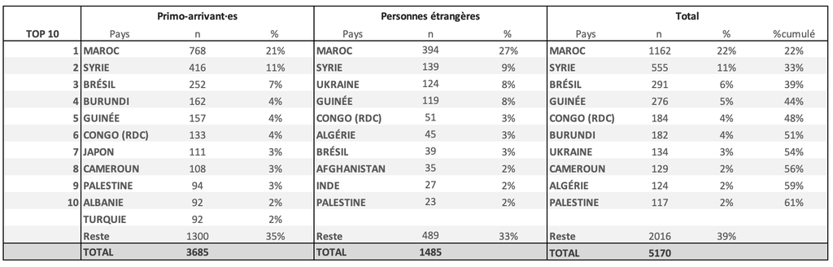

Top 10 des nationalités plus représentées des publics nouvellement inscrit·es en 2025.

Les personnes originaires du Brésil occupent désormais la troisième position. Alors qu’elles étaient presque absentes du parcours d’accueil avant l’instauration de l’obligation de suivi, leur présence a fortement augmenté ces dernières années, presque exclusivement parmi les primo-arrivant·es. Cette évolution constitue un exemple emblématique des effets des réformes de 2022 qui ont contribué à **diversifier les origines**[^36] des usager·ères avec **l’apparition de nouvelles nationalités.** Parmi d’autres cas, pointons l’apparition, principalement chez les primo-arrivant·es obligé·es, de la **nationalité japonaise** et pour la première fois, de la nationalité albanaise (2%).

Par ailleurs, les réformes ont également contribué à **renforcer** **certaines nationalités** déjà présentes avant 2022, tendance qui se confirme encore aujourd’hui, notamment pour le Burundi, le Congo (RDC), le Cameroun et l’Algérie. Il s’agit surtout des personnes originaires de pays post-coloniaux où la langue française demeure présente, de sorte qu’une partie d’entre elle arrive avec des **besoins linguistiques moins importants** *(cf. sous-section Bilan linguistique*)**.**

Cette année, la Palestine fait son entrée dans le top 10 des nationalités les plus représentées, dans les deux catégories de public. Cette progression est particulièrement marquée parmi les primo-arrivant·es et reflète l’augmentation des demandes de protections internationales par des personnes palestiniennes au cours des deux dernières années (*cf. partie Contexte territorial*).

On note également une **augmentation soutenue de la part des usager·ères ukrainien·nes depuis 2021** (Figure 11), désormais en troisième position parmi les personnes étrangères (+1 points de pourcentage). Il s’agit souvent des ancien·nes bénéficiaires BPTU souhaitant soit prolonger leur apprentissage du français, soit faire une demande de nationalité ultérieurement. En revanche, la part des personnes de **nationalité indienne** **poursuit sa baisse** (-1pp). Ce public sort pour la première fois du top dix global tout en restant faiblement représentés parmi les personnes étrangères (2%). En trois ans, leur représentation a chuté de 11pp., et depuis 2019, de 19pp.

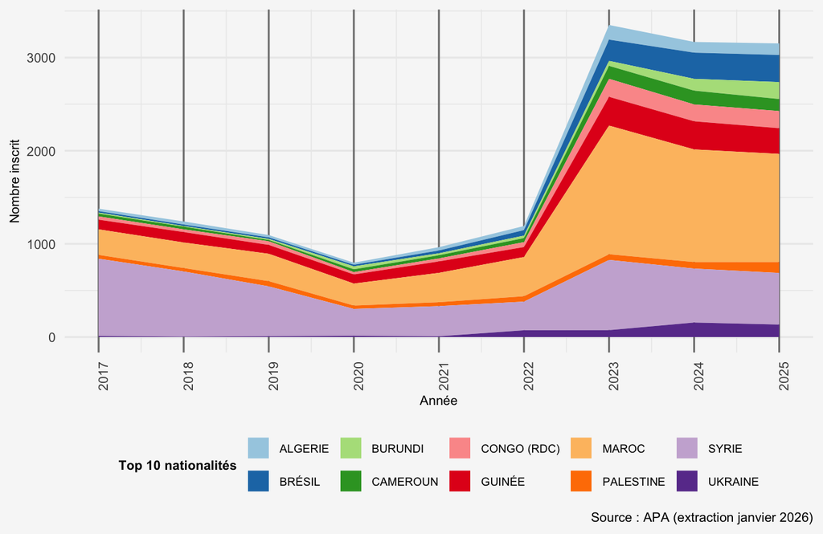

Figure 11: Évolution des 10 premières nationalités du public inscrit de 2025.

## 4.2 Situation sociodémographique : genre, âge et composition du ménage

### 4.2.1 Genre

En 2025, **les femmes continuent d’être majoritairement présentes dans le parcours**, comptant 60% du public inscrit contre 40% d’hommes[^37].

### 4.2.2 Age

En ce qui concerne l’âge, on retrouve les mêmes contrastes entre les catégories du public où **les primo-arrivant·es représentent un public plus jeune que les personnes étrangères**. Si la moitié du public inscrit a 36 ans ou moins, l’âge médian des primo-arrivant·es est de 35 ans, tandis que pour les personnes étrangères, il atteint 39 ans.

### 4.2.3 Composition de ménage

**Note**

Les trois indicateurs qui suivent (composition de ménage, situation professionnelle et plus haut diplôme) sont recueillies lors du bilan social. Toutefois, 15% des personnes inscrites en 2025, ne l’ont pas encore fait. Nous avons exclu des analyses les dossiers pour lesquels les informations sont manquantes en raison de l’absence de réalisation du bilan social. Cette exclusion vise à garantir la robustesse des analyses et à éviter de confondre différentes sources de données manquantes, telles que le refus de répondre à certaines questions ou la non-réalisation du bilan social.

Par souci de lisibilité, le terme « inscrit » sera utilisé dans ces analyses pour désigner les **personnes** **inscrites** et **ayant réalisé un bilan social.**

Du point de vue du genre (Figure 12), on observe une **surreprésentation des femmes dans les catégories de ménage ayant des enfants à charge** : elles sont plus nombreuses que les hommes à vivre en couple avec des enfant(s) (46% contre 32%) ou à constituer des familles monoparentales (16% contre 6%). Tandis que, **les hommes sont plus fréquemment représentés** en tant qu’isolés (25% contre 8%). Ces différences dans la composition des ménages reflètent à la fois des **réalités systémiques de genre,** à Bruxelles, 87% des familles monoparentales sont représentées par des femmes (Focus n°74, IBSA, 2025, p.6), et **des dynamiques de genre spécifiques à la migration**. En effet, les hommes migrent plus fréquemment seuls dans un premier temps, en tant que personne isolée avant d’initier, le cas échéant, une procédure de regroupement familial (*cf. infra)*.

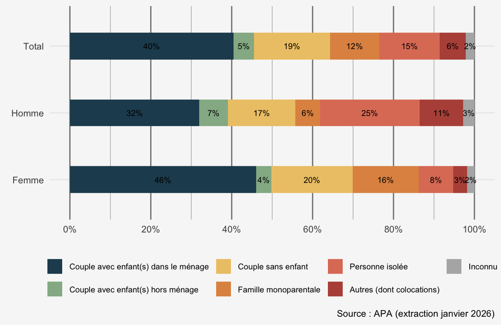

Figure 12: Répartition du public inscrit selon la composition du ménage et le genre.

La comparaison des situations des ménages selon les deux types de publics, met en évidences des différences significatives. Les primo-arrivant·es sont davantage représenté·es en couple sans enfants (19%) que les personnes étrangères (8%). A l’inverse, ces dernières se retrouvent plus fréquemment en couple avec enfant(s) dans le ménage (40%), en tant que personnes isolées (15%) ou en situation de monoparentalité (17%). Ces écart peuvent s’expliquer par une différence de temporalité dans la carrière d’installation. Les primo-arrivant·es étant tenu·es de s’inscrire dans le parcours d’accueil dès le début de leur installation, il est plus probable que la question de la parentalité — ou la présence d’enfants dans le ménage — n’intervienne que plus tard. À l’inverse les personnes étrangères — en particulier celles installées depuis plus de 3 ans — sont plus susceptibles d’avoir des configurations familiales qui évoluent (avec naissance d’enfants ou monoparentalité).

## 4.3 Situation socio-professionnelle : revenus et plus hauts diplômes obtenus

Certain·es usager·ères des Bapas font face à une grande précarité, liée notamment à leur situation socioprofessionnelle. Parmi les personnes inscrites[^38] en 2025, **la moitié est inactive (52%)** : 18% sont allocataires du RIS[^39] et 34% ne perçoivent pas de revenus.

L’évolution des situations socio-professionnelles des publics inscrits depuis 2017 (Figure 13) montre une tendance à la **concentration autour de deux situations opposées** : **les personnes en emploi et celles sans revenus**. Cette évolution s’explique par la diminution de la proportion d’allocataires du RIS depuis 2020, accompagnée par la progression des personnes en emploi depuis l’obligation. La diminution continue du nombre d’allocataires du RIS s’explique par l’augmentation des usager·ères en regroupement familial, en particulier des femmes (16% perçoivent le RIS contre 21% des hommes), souvent exclues des aides sociales et dépendantes financièrement du conjoint.

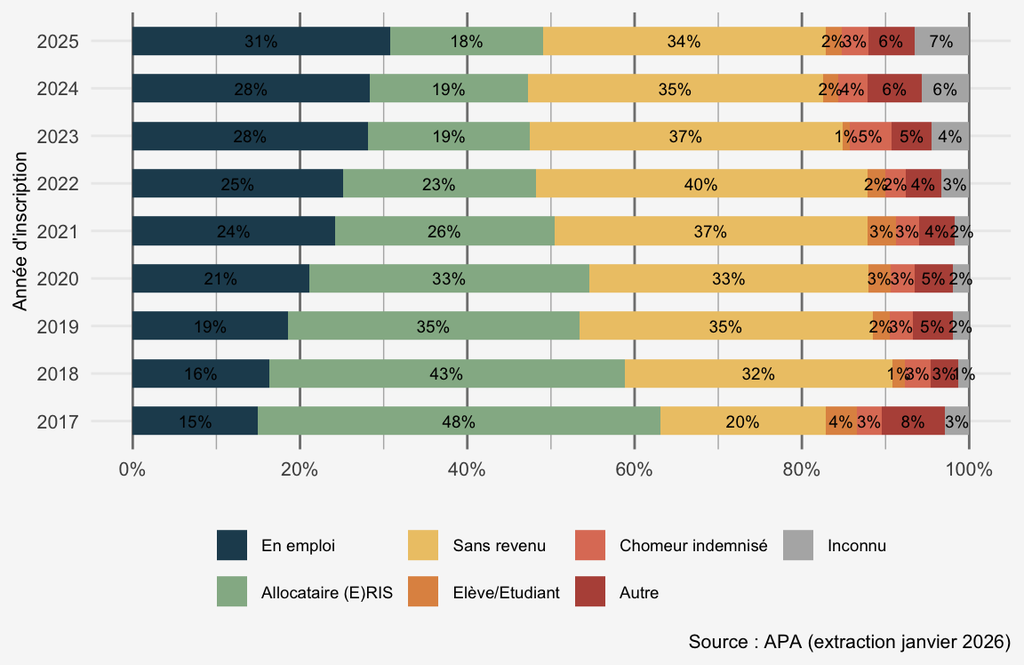

Figure 13: Évolution des situations socio-professionnelles du public inscrit (2017-2025).

L’augmentation de la présence du public en emploi soulève plusieurs difficultés, pour les Bapas[^40] :

- d’une part, pour les travailleur·euses il s’agit de dossiers administrativement lourds, s’agissant d’un public moins disponible[^41], les TS sont amené·es à gérer une multiplicité de suspensions avec les communes ;
- d’autre part, pour les directions et coordinations la pression à organiser des formations en horaire décalé, plus couteuses et plus difficiles à organiser (cf. infra) ;

Enfin, bien que le public sans revenus demeure le plus représenté, sa part diminue pour la troisième année consécutive. Cette situation concerne davantage les primo-arrivant·es, qui sont surreprésenté·es dans cette catégorie (+11 pp.) en raison de leur arrivée relativement récente en Belgique et leur prédominance à être en regroupement familial (60% contre 56% des personnes étrangères). Parmi ce public, certaines personnes se trouvent dans des situations de grande précarité, voire de *sans chez soirisme*, pour lesquelles un accompagnement social renforcé s’avère particulièrement nécessaire[^42]. De leur côté, les personnes étrangères sont davantage représentées en tant que chomeur·euses indemnisé·es (9% contre 1% chez les primo-arrivant·es).

En termes de genre, les disparités entre hommes et femmes se creusent (Figure 14). **Les femmes sont majoritairement sans revenus** (48% contre 13% des hommes), tandis que **les hommes sont plus souvent en emploi** (47% contre 20% des femmes). Comme le mentionnent les Bapas, la précarité augmente chez les femmes. Si certaines choisissent de rester au foyer, d’autres se retrouvent dépendantes de leur conjoint·e en raison de leur statut de résidence, voire sont totalement privées de ressources, et parfois prises dans des situations de violences conjugales et/ou familiales[^43].

Toutefois, il convient aussi de nuancer la situation des personnes en emploi. Celle-ci n’équivaut en effet pas à une situation socio-économique toujours pérenne et stable, mais recouvre souvent des contrats précaires (emplois à temps partiels, « flexibles », en intérims, ou sous CDD). En outre, le travail non déclaré, par définition non recensé, échappe à ces statistiques.

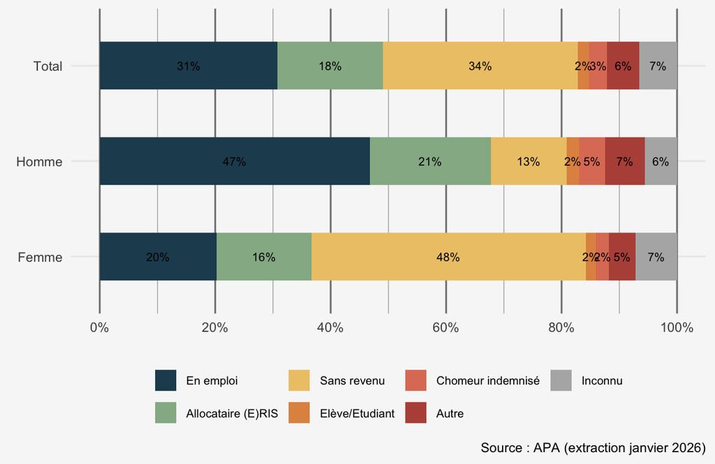

Figure 14: Répartition des situations socio-professionnelles du public inscrit selon le genre

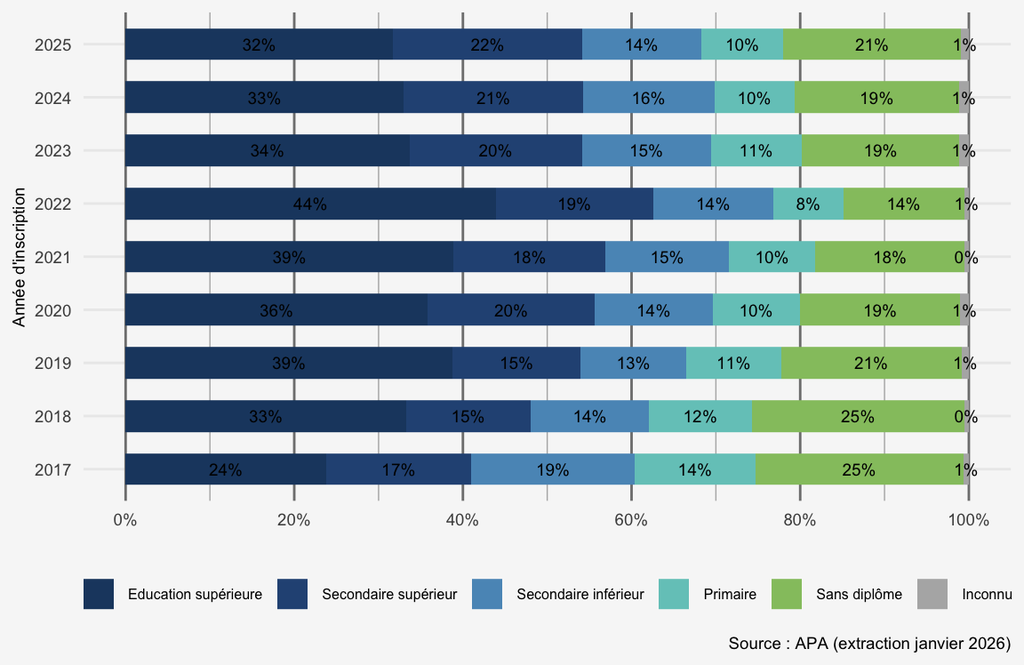

Figure 15: Évolution du plus haut diplôme obtenu à l’étranger ou en Belgique (2017-2025).

Cet indicateur varie légèrement selon les catégories de public (Figure 16) :

- **Les personnes étrangères sont plus souvent « infra-diplômé·es »** et concerne la moitié de ce public ;
- **Les primo-arrivant·es sont plus souvent détenteur·trices au minimum d’un diplôme du CESS** (56%).

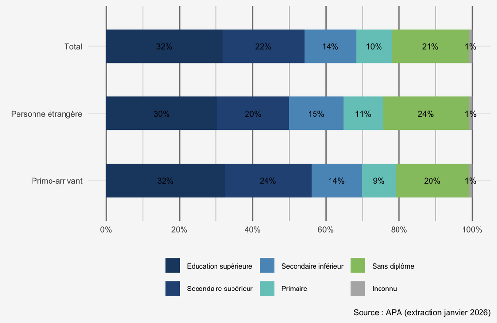

Figure 16: Répartition du plus haut diplôme obtenu à l’étranger ou en Belgique selon la catégorie de public

## 4.4 Situation socio-juridique : titres et motifs de séjour

La répartition des motifs de séjour demeure globalement similaire à celle observée l’année dernière, malgré une légère augmentation des motifs humanitaires et médicaux (Figure 17). **Le regroupement familial** reste de loin le principal motif de séjour (59%), devant les **protections internationales (réfugiés et protections subsidiaires)** (20%). Bien que les autorités fédérales aient durci les conditions du regroupement familial en juin 2025, aucun effet quantitatif n’est encore observable dans les données. Sur le terrain, les Bapas rapportent toutefois une augmentation du stress et de l’incertitude parmi le public concerné par cette mesure[^45].

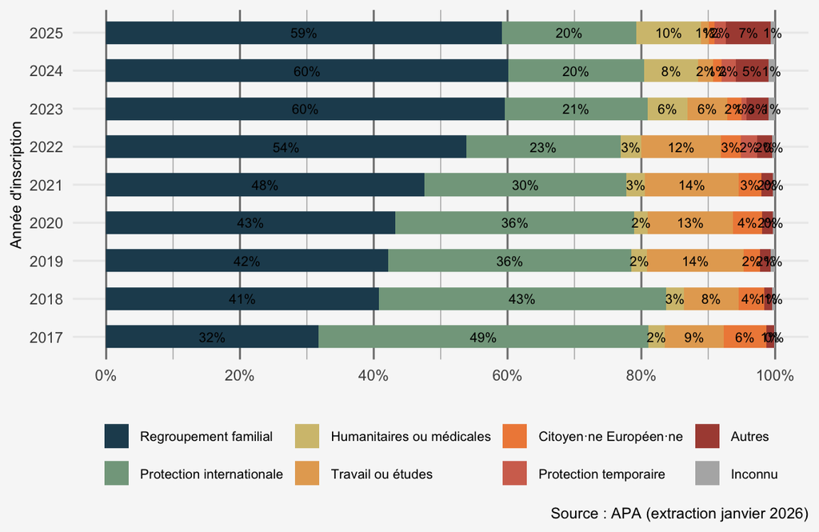

Figure 17: Évolution du public inscrit selon les motifs de délivrance de séjour (2017-2025).

En ce qui concerne les catégories d’usager·ères, les **motifs de séjour des primo-arrivant·es se concentrent autour de quatre raisons principales** : 60% par regroupement familial, 19 % au titre de la protection internationale, 12 % pour raisons médicales ou humanitaires, et 8 % pour d’autres motifs. À l’inverse, **les personnes étrangères présentent des motifs de séjour plus diversifiés**, bien que la majorité concerne aussi le regroupement familial (56 %) et la protection internationale (22 %). Les autres motifs relèvent principalement d’exemptions prévues par la législation, comme le statut de citoyen·ne européen·ne, la protection temporaire, le travail ou les études.

Enfin, en termes de genre, des différences de répartition apparaissent. **La majorité des femmes arrivent via le regroupement familial (67 %)**, tandis que seules 11% sont bénéficiaires de la protection internationale. **Chez les hommes, la répartition est plus équilibrée** : 47 % par le regroupement familial et 34 % au titre de la protection internationale.

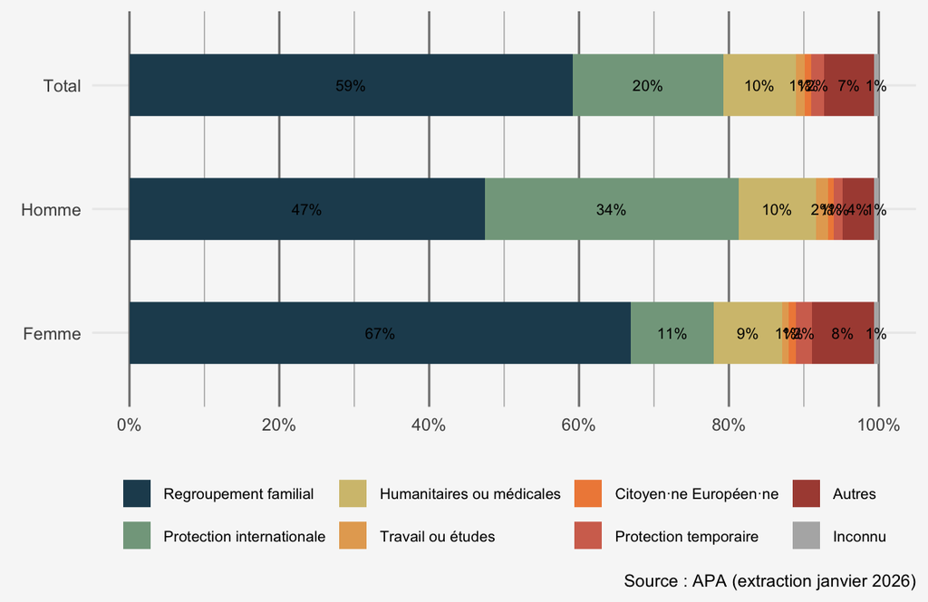

Figure 18: Usager·ères inscrit·es en 2025 selon les motifs de délivrance de séjour par genre.

Pour l’analyse des cartes de séjour, nous ferons la distinction entre les **séjours limités** et les **séjours illimités**[^46]. La durée du séjour constitue un enjeu central en matière de **précarité administrative**, ainsi que dans les conditions d’accès et de suivi du Parcours d’accueil.

- Les **séjours limités sont majoritaires et représentent 53% du public** : 46% sont des cartes A, dont la part ne cesse d’augmenter depuis 2023 (+9pp.), et 7% des cartes oranges ;
- Parmi les **séjours illimités**, les **cartes F et F+** liées au regroupement familial, constituent la deuxième catégorie la plus représentée (38%) et demeurent stables. La part des **cartes B, détenues exclusivement par des personnes étrangères**[^47], atteint son niveau le plus bas depuis que la création du dispositif.

Sans surprise, le **public primo-arrivant** est majoritairement concerné par **les séjours limités** (soit 64%), **plus de la moitié ont des cartes A** et **plus d’un tiers est titulaire d’une carte F ou F+**. Ensuite 9%, soit 349 primo-arrivant·es, ont une carte orange, correspondant en réalité à une attestation d’immatriculation. Or, la durée de validité de celle-ci est comprise entre 3 et 9 mois. Cette situation engendre une incompatibilité entre le cadre temporel des titres de séjour et celui du Parcours d’accueil, tout en générant une charge administrative importante dans la gestion de ces dossiers. En effet, en 2025, l’APA enregistre 713 interruptions de parcours par les communes, parmi lesquelles 56% concernent des cartes A et 29% des cartes oranges (209 cas, soit 60% des PA en carte orange).

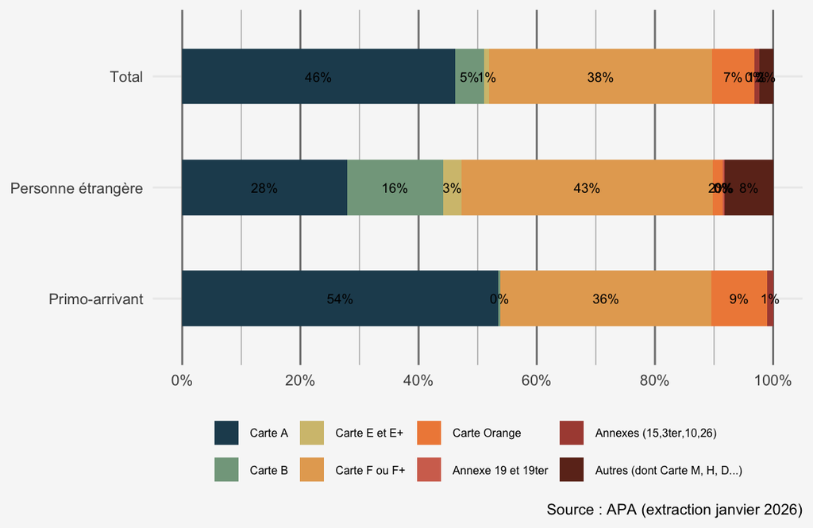

Figure 19: Usager·ères inscrit·es en 2025 selon le type de carte de séjour par catégorie de public.

## 4.5 Géographie résidentielle : communes de résidence

En ce qui concerne la géographie résidentielle, en 2025 le public continue de se concentrer majoritairement dans les cinq communes d’implantation des Bapas, où résident **59% des usager·ères**. Parmi celles-ci, Bruxelles-Ville retrouve la première position (Figure 20) et représente à elle seule 19% des nouvelles inscriptions (+4,5 pp. par rapport à 2024). Anderlecht (12,9%) et Molenbeek (11,9%) conservent également une place importante, bien que la première enregistre une légère diminution tandis que la seconde demeure relativement stable.

**Les communes de deuxième couronne**, dont la représentation avait progressé à la suite de l’entrée en vigueur de l’obligation de suivi, restent présentes dans le dispositif. C’est notamment le cas de Uccle, Auderghem, Ganshoren et Woluwe-Saint-Pierre, même si leur poids demeure limité (Table 3).

| Commune de résidence | Primo-arrivant·es Effectif | Primo-arrivant·es Part (%) | Personnes étrangères Effectif | Personnes étrangères Part (%) | Total Effectif | Total Part (%) |
| --- | --- | --- | --- | --- | --- | --- |
| Total | 3 682 | 100% | 1 485 | 100% | 5 167 | 100% |
| Bruxelles-Ville | 769 | 20.9% | 220 | 14.8% | 989 | 19.1% |
| Anderlecht | 413 | 11.2% | 255 | 17.2% | 668 | 12.9% |
| Molenbeek-Saint-Jean | 450 | 12.2% | 164 | 11% | 614 | 11.9% |
| Schaerbeek | 311 | 8.4% | 190 | 12.8% | 501 | 9.7% |
| Ixelles | 297 | 8.1% | 72 | 4.8% | 369 | 7.1% |
| Saint-Gilles | 266 | 7.2% | 58 | 3.9% | 324 | 6.3% |
| Forest | 159 | 4.3% | 122 | 8.2% | 281 | 5.4% |
| Uccle | 200 | 5.4% | 81 | 5.5% | 281 | 5.4% |
| Jette | 121 | 3.3% | 68 | 4.6% | 189 | 3.7% |
| Saint-Josse-Ten-Noode | 155 | 4.2% | 31 | 2.1% | 186 | 3.6% |
| Auderghem | 97 | 2.6% | 20 | 1.3% | 117 | 2.3% |
| Koekelberg | 82 | 2.2% | 33 | 2.2% | 115 | 2.2% |
| Woluwe-Saint-Pierre | 76 | 2.1% | 14 | 0.9% | 90 | 1.7% |
| Etterbeek | 49 | 1.3% | 35 | 2.4% | 84 | 1.6% |
| Woluwe-Saint-Lambert | 43 | 1.2% | 42 | 2.8% | 85 | 1.6% |
| Evere | 36 | 1% | 42 | 2.8% | 78 | 1.5% |
| Berchem-Sainte-Agathe | 44 | 1.2% | 18 | 1.2% | 62 | 1.2% |
| Ganshoren | 48 | 1.3% | 8 | 0.5% | 56 | 1.1% |
| Watermael-Boitsfort | 41 | 1.1% | 12 | 0.8% | 53 | 1% |
| Inconnu | 25 | 0.7% | 0 | 0% | 25 | 0.5% |

Source : APA (extraction janvier 2026)

Table 3: Usager·ères inscrit·es en 2025 selon la commune de résidence et la catégorie de public

Certaines évolutions méritent toutefois d’être soulignées. La représentativité de la commune de Saint-Gilles augmente (+2pp.), principalement sous l’effet d’une augmentation du nombre de primo-arrivant·es, tandis qu’Etterbeek connaît une évolution inverse. Ensuite, Uccle qui se distinguait jusqu’ici par une surreprésentation de primo-arrivant·es, présente désormais un poids plus équilibré entre publics prioritaires et non prioritaires.

L’analyse par catégorie de public met également en évidence des spécificités territoriales. Les primo-arrivant·es sont surreprésenté·es à Bruxelles-Ville, Ixelles, Saint-Gilles, Saint-Josse et Auderghem, tandis que les personnes étrangères le sont davantage à Anderlecht, Schaerbeek, Forest et Jette.

Enfin, pour la deuxième année consécutive, **la commune d’Evere connaît une baisse** et enregistre une diminution de 4,5 pp. par rapport à la période 2016-2022 (Figure 20). Le nombre d’usager·ères d’Evere atteint **l’un de ses niveaux les plus faibles depuis la création du dispositif**. Cette évolution s’explique par une **surreprésentation historique** de cette commune au sein du parcours d’accueil[^48].

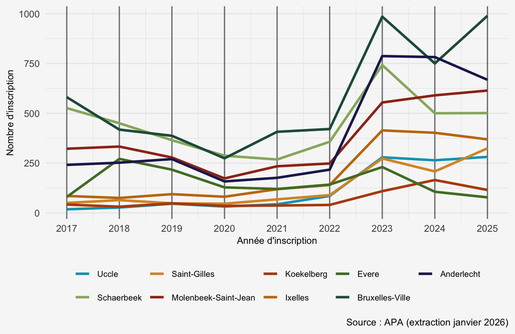

Figure 20: Évolution du public inscrit selon la commune de résidence (2017-2025).

En conclusion, en 2025, les profils des usager·ères affichaient des tendances très similaires à celles de 2024. Les réformes législatives ont amené un public plus diversifié en termes de nationalités mais ont aussi eu un effet de concentration, notamment dans les motifs de séjour, les diplômes et les situations socio-professionnelles. En dernière analyse, ces réformes ont eu tendance à élargir le bassin de recrutement des Bapas.

# 5 ACTIONS MISES EN ŒUVRE PAR LES BAPAS

## 5.1 Programme d’accueil

### 5.1.1 Bilan social

Le bilan social (BS) consiste en un premier contact avec un·e assistant·e social·e, moment essentiel pour instaurer une relation de confiance afin d’identifier les besoins et les connaissances de l’usager·ère. Ce temps d’échange permet de définir les objectifs et stratégies à mettre en place pour la suite du parcours en termes d’orientation et accompagnement vers d’autres services spécialisés, ou encore à rechercher des solutions en cas d’urgence (relais vers des services psychologiques, du logement, de l’aide matérielle…).

Pour évaluer l’efficacité du parcours à ce stade, nous comparons la part ayant réalisé un bilan social la même année. Parmi les 5.167 personnes nouvellement inscrites en 2025, **84 % ont réalisé un bilan social**, soit 4.350 usager·ères. Cet indicateur reste proche de la moyenne des six dernières années, se situant à 86 %. Cette stabilité est positive et suggère qu’il n’y a pas de report de charge supplémentaire qui se crée en ce qui concerne le travail des TS.

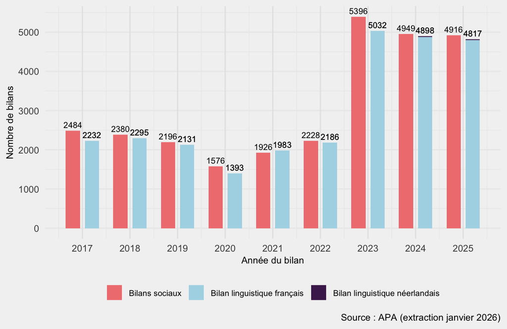

Figure 21: Évolution du nombre de bilans sociaux et linguistiques (2017-2025).

### 5.1.2 Bilan linguistique

Le **bilan linguistique** (BL) sert à évaluer les compétences linguistiques en français ou en néerlandais de l’usager·ères et le·la positionner[^49] au sein des différents niveaux de formations (filières et modules). Ce bilan est réalisé en vue de l’inscription de la personne à un premier module auprès des opérateurs linguistiques, lorsque le niveau pressenti est inférieur au A2 du CECR (Art 13, Arrêté COCOM 2024*)*. En ce qui concerne la langue choisie du parcours, la quasi-totalité des usager·ères (99%) optent pour le français.

En 2025, on dénombre **4.817 bilans linguistiques** réalisés : dont 99,7% (soit 4.801 bilans) dans les trois Bapas et 16 auprès de la Huis van het Nederlands. Pour ces derniers, ce sont les usager·ères qui se chargent de communiquer le résultat aux Bapas pour les encoder dans l’APA.

Parmi les usager·ères ayant déjà le niveau A2 de français, plusieurs constats peuvent être relevés :

- leur proportion continue d’augmenter (+3pp. par rapport à 2024) ;
- la majorité d’entre eux et elles ont été positionné·es directement dans un Bapas (78% contre 22% qui ont présenté une attestation reconnue). Parmi ces personnes positionnées par les Bapas, 80% ont été évaluées dans une filière FLE et 20% dans une filière d’alphabétisation ;
- les personnes étrangères disposent plus fréquemment du niveau de français requis que les primo-arrivant·es : 75% d’entre elles contre 46% des primo-arrivant·es. Toutefois, lorsque leur niveau est évalué par les Bapas, les personnes étrangères sont (en proportion) plus souvent testées dans une filière d’alphabétisation, tandis que les primo-arrivant·es sont davantage testé·es en FLE.

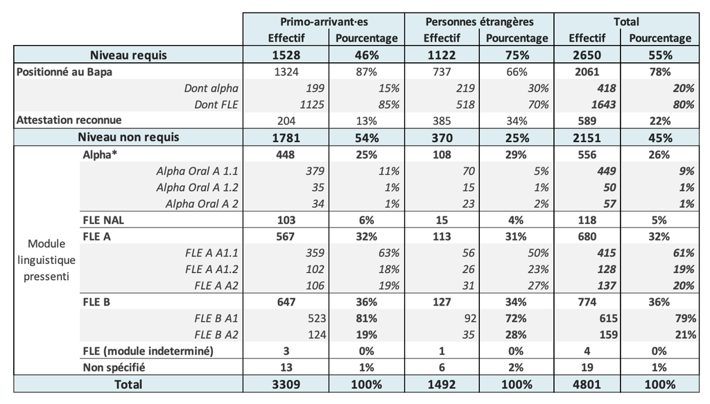

Répartition des usager·ères selon leur niveau de français et selon la catégorie d’usager·ère.

Au total, **2.151 personnes ont été positionnées dans des modules linguistiques,** selon une répartition en sous-filière comme suit : **26% en Alpha, 5% en FLE NAL, 32% en FLE A et 36% en FLE B.** En 2025, la part de la filière FLE B diminue légèrement (-3,5pp.) au profit des filières d’alphabétisation et de FLE A. En termes de genre, il n’existe pas de différences majeures dans le positionnement linguistique, si ce n’est que les femmes sont plus représentées en FLE B et les hommes légèrement plus en FLE A.

Si la filière FLE B continue d’être la plus importante, des spécificités existent selon les catégories d’usagers·ères. **Les personnes étrangères sont plus souvent orientées vers la filière d’alphabétisation** que les primo-arrivant·es (29% contre 25%), **alors que les primo-arrivant sont davantage dirigé·es vers la filière FLE B que les personnes étrangères** (36% contre 34%). La filière FLE A présente quant à elle une répartition plus équilibrée entre les deux publics.

### 5.1.3 Information Droits et Devoirs

Les modules « droits et devoirs » (DD) sont en règle générale dispensés par les accompagnateurs·rices sociaux·ales ou par les formateurs·trices. Toutefois, certains modules proposés en langues rares (Dari, Farsi, Pashto, etc.) peuvent nécessiter l’intervention d’un·e interprète, que ce soit un·e travailleur·se social·e (au sein des Bapas) ou externe (e.g. : SETIS, Bruxelles Accueil).

En 2025, **seul 89 modules**[^50] **DD ont été organisés**, soit presque la moitié qu’en 2024, par la fusion des modules DD avec les formations citoyennes en modules 60 heures conformément à l’Article 16 de l’Arrêté COCOM de 2024. VIA a organisé 77 modules de DD, Convivial 7 et BAPA-BXL 5. Ils ont formé au total 1.538 participant·es.

En 2025, ces modules sont dispensés dans **11 langues**, mais dans des proportions différentes : **39 % des modules sont réalisés dans l’une des langues arabes**[^51]**, 38% en français (28% en français et 10% en français facile), et 10% en anglais**.

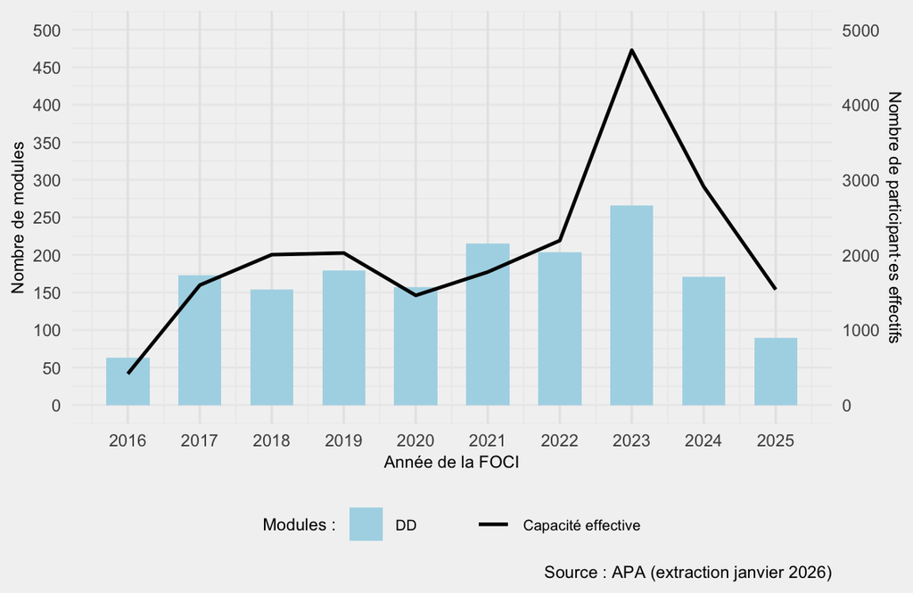

## 5.2 Composantes de l’offre

### 5.2.1 L’accompagnement social

L’accompagnement social constitue une composante essentielle de l’offre des Bapas, particulièrement pour les publics les plus vulnérables. Réalisé par un·e assistant·e sociale, cet accompagnement débute dès la phase du bilan social et, tel que le précise la législation, repose sur « *l’évaluation continue de la situation du bénéficiaire tout au long du parcours d’accueil, dans le soutien du bénéficiaire dans les démarches qu’il entreprend en vue de son insertion sociale et professionnelle et, le cas échéant, dans son orientation vers d’autres dispositifs, y compris pour le renforcement de ses compétences linguistiques* » (*Art 17, Arrêté COCOM 2024).*

Si les besoins d’accompagnement varient d’une personne à l’autre, les rapports d’activités des Bapas montrent que **les demandes les plus fréquentes** portent sur :

- Les **démarches administratives et juridiques** relatives au parcours lui-même ou à des services et dispositifs externes (communes, CPAS, syndicats, titre de séjour, regroupement familial…) ;
- La **digitalisation croissante des services** (difficulté particulièrement rencontrée par le public en alphabétisation, première victime de la fracture numérique) ;
- La **recherche d’un logement** ;
- Les **difficultés financières** (perte de revenus, déclaration fiscale à compléter, médiation de dette et plans de paiement…) ;
- La **recherche d’une formation professionnelle et/ou d’un emploi** (Orientation ISP) ;
- Les démarches liées à **l’inscription des enfants en crèche ou à l’école** ;
- La **santé (mentale ou physique) et** **l’accès au soin** (pour les personnes elles-mêmes ou une personne à charge) ;
- Les **violences intra-familiales**, en particulier conjugales (phénomène dont la visibilité a augmenté depuis l’entrée en vigueur de l’obligation de suivi du parcours d’accueil) ;
- La **vie sociale et culturelle** des usager·ères (demandes d’activités, etc.)

L’accompagnement social prend deux formes : **l’accompagnement direct et l’orientation**. Cette dernière dépend du type de besoin exprimé et du profil de l’usager·ère (notamment son niveau de langue).

Si l’**orientation vers des services externes** au Bapa est parfois justifiée comme favorisant la « mise en autonomie » des usager·ères – ces derniers·ères étant ainsi invité·es à se familiariser avec d’autres services susceptibles de répondre à leurs besoins –, l’orientation est aussi une pratique devenue indispensable dans un contexte de saturation des Bureaux d’accueil. Comme le souligne bien un Bapa dans son rapport d’activités, lorsque les usager·ères sont « invités à se tourner vers d’autres services […], il s’agit à la fois de les rassurer et d’éviter qu’ils ne concentrent toutes leurs demandes auprès de leur accompagnateur social référent »[^52]. Néanmoins, l’orientation externe se heurte également à la saturation de certaines associations partenaires, en particulier celles qui sont spécialisées dans l’aide juridique.

Les Bapas orientent aussi **vers des services internes** qui ont été développés, permettant de soulager les assistant·es sociaux·ales et de répondre aux besoins spécifiques (juridiques ou psychologiques) des publics. À côté de ces services internes, les trois Bapas ont également développé des activités pour lutter contre l’isolement social (tables de conversation), les inégalités de genre (ateliers pour femmes), ou plus récemment la fracture numérique (ateliers informatiques).

Cette tendance à « l’orientation interne » se marque particulièrement en ce qui concerne **l’Insertion socio-professionnelle (ISP)** – une composante prioritaire pour les Bapas dans l’accompagnement social. En effet, face au constat des nombreux écueils rencontrés par les usager·ères dans leur orientation vers les services ISP « classiques », les bureaux d’accueil ont mené depuis 2019 des initiatives spécifiques (guidance et projets de « coaching professionnel » individuel, activité de « pré-ISP »…).

Malgré son caractère essentiel, l’accompagnement social est cependant l’une des composantes du Parcours d’accueil les plus mise à mal par la saturation du dispositif. Les réformes de 2022 ont amené une **inflation du travail administratif** (gestion de la liste d’attente et des attestations, (dés)inscriptions aux formations, suspensions pour raisons professionnelles, exemptions, erreurs de détection, sommations…) qui entraîne une diminution du temps que les travailleurs·euses sociaux·ales peuvent dédier à l’écoute et à la construction d’une relation de confiance avec les usager·ères[^53].

Par ailleurs, en dehors des effets de la saturation, les assistant·es sociaux·ales font également face à d’autres difficultés sur le terrain dont les plus récurrentes sont :

- Le **manque de disponibilité de certains publics**, pour des raisons de santé ou qui priorisent d’autres démarches essentielles à leur installation (activité professionnelle ou recherche d’emploi, charge domestique, procédure de regroupement familial…). Ces indisponibilités rendent le suivi des TS particulièrement chronophage (rappels fréquents, absences aux rendez-vous, désistements aux formations…) ;
- La **complexité de l’accompagnement des publics victimes de violences conjugales**, qui demande un suivi plus long et délicat ;
- Le sentiment d’**impuissance des TS face aux demandes concernant le logement** (manque de solutions concrètes, saturation des dispositifs existants et situation du marché immobilier bruxellois) ;
- L’**usage de fausses attestations** (notamment linguistiques), ce qui nécessite un travail de prévention et de détection. Le recours à ces faux révèle également l’importance des enjeux liés à l’obtention d’une attestation, en particulier en ce qui concerne les PE en demande de nationalité ;
- La **barrière linguistique** entre les travailleurs·euses sociaux·ales et les personnes accompagnées constitue – *de facto* – un frein à la bonne compréhension des informations délivrées[^54]. Plus encore, la **méconnaissance d’une des langues nationales** « rend le public particulièrement dépendant des travailleurs sociaux pour toutes les démarches sociales à accomplir »[^55]. Si « cela constitue un frein important à l’autonomisation des bénéficiaires »[^56], cela accroit aussi – dans un contexte de saturation du parcours – la charge de travail des TS.

### 5.2.2 La formation à la citoyenneté

La formation à la citoyenneté (FOCI) *« a une durée de minimum cinquante heures. […] Elle est dispensée à des groupes de maximum vingt bénéficiaires par un formateur disposant de compétence pédagogique et titulaire d’une attestation de formation de formateur à la citoyenneté délivrée par un organisme de formation reconnu ou agréé, ainsi que d’une attestation de formation continuée en cours de validité délivrée par ce même type d’organisme. »* (*Art 18, Arrêté COCOM 2024).* Les grandes thématiques de cette formation sont définies par l’Arrêté d’exécution (2024), à savoir : *« l’histoire de la Belgique y compris l’histoire des migrations, l’organisation politique et institutionnelle de la Belgique, la géographie de la Belgique, le caractère multiculturel de la Belgique, l’organisation socio-économique de la Belgique, le système de sécurité sociale belge, l’organisation du marché de l’emploi ainsi que les modalités de participation. » (Art. 19, Arrêté COCOM 2024).*

En 2025, les Bapas ont organisé **190 modules de « formation citoyenne »**, soit 17 modules en plus par rapport à 2024 (+10%). Cette année, les modules en format long de 60h deviennent majoritaires (114 modules soit 60%), contre les 76 modules en format classique de 50h. Convivial propose exclusivement des formations de 60h, BAPA-BXL majoritairement également, tandis que VIA reste en 50h mais passera au format 60h en aout 2026[^57]. La part des modules assurés par des partenaires externes, notamment le Setis et La Chambre de l’Art et de la Culture, augmente (+8 modules) et représente 13% de l’offre en 2025.

Au total **3.597 usager·ères ont participé à une FOCI en 2025,** soit une augmentation de 7% par rapport à 2024 et de 54% depuis 2023. La taille moyenne des modules de formation est de 19 participant·es[^58]. L’évolution du nombre de participant·es et de modules révèlent les efforts que les Bapas ont fait depuis les réformes de 2022 pour accroître leur capacité effective afin de se rapprocher de la demande, qui ne cesse d’augmenter.

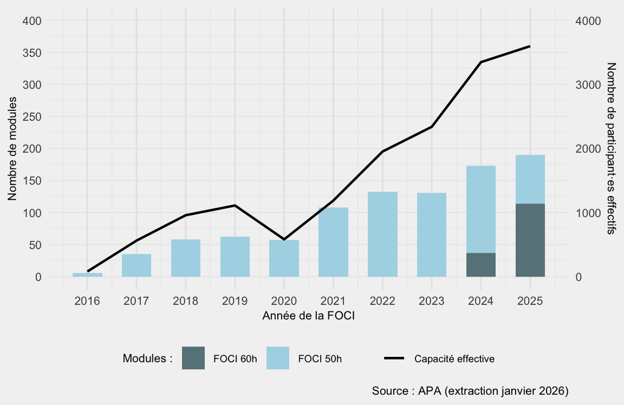

Figure 23: Évolution du nombre d’usager·ère ayant suivi une FOCI et du nombre de FOCI (2016-2025).

En 2025, les modules de citoyenneté sont dispensés en **8 langues**[^59]. **Les modules en français restent majoritaires** (52% dont 13% en français facile), devant l’arabe (33%) et l’anglais (10%). L’offre s’est diversifiée avec le développement de modules en anglais facile[^60] et l’augmentation des modules en espagnol et en japonais, reflétant l’évolution des publics accueillis par les Bapas. Des variations persistent entre les Bapas selon les profils des usager·ères (cf. Rapport d’activités 2025 des Bapas).

Au total, **20 modules ont été dispensés en horaire décalé**, soit sept de plus qu’en 2024. La demande d’offre en décalé ne cesse d’augmenter notamment pour le public en emploi ou en formation, si les Bapas font des efforts pour accroitre l’offre en décalé, les contraintes budgétaires limitent leur capacité à en organiser.

**L’offre en FOCI n’est structurellement pas suffisante et ne permet pas de désengorger** les Bapas. En effet, la capacité de formation couvre 70% des nouvelles inscriptions et par conséquence le dispositif crée automatiquement 30% de report de charge en un an (sans compter le report déjà existant). **Les capacités financières actuelles** ne permettent pas d’organiser davantage de modules. Cette contrainte budgétaire entraîne un allongement du délai entre l’inscription au Bapa et le début de la formation : la moitié des usager·ères doivent attendre au moins 5 mois.

### 5.2.3 La formation linguistique

La formation linguistique est la seule composante qui **est mise en œuvre par des opérateurs tiers**. Les Bapas orientent leur public vers des organismes reconnus pour les formations de français et la Huis van het Nederlands centralise l’offre néerlandophone (Art. 21, Arrêté COCOM 2024).

En ce qui concerne l’orientation vers les opérateurs francophones, **les Bapas** – qui réalisent les bilans linguistiques, inscrivent les usager·ères dans des modules de formation (et donc composent les groupes), et assurent le suivi de la formation (rappel du début, prise en charge des éventuels redoublements, etc.) — collaborent nécessairement avec **les opérateurs linguistiques** qui dispensent les formations et remettent l’attestation de suivi.

Le tableau ci-dessous montre que les usager·ères qui doivent suivre une formation linguistique sont très largement (**91%**) orienté·es vers **les 16 opérateurs conventionnés**. La part des opérateurs conventionnés augmente légèrement par rapport à 2023 et le nombre de personnes inscrites auprès d’opérateurs reconnus en Cohésion Sociale (spécialisés dans l’alphabétisation (P2)), chute : passant de 83 inscrit·es en 2023 à 14 en 2024. Le reste des usager·ères sont orientés vers des établissements de la Promotion Social, dont l’évolution de la collaboration est salué positivement par les Bapas.

| Type d'opérateur | Nombre d'inscriptions | Part (%) |
| --- | --- | --- |
| Bruxelles-Formation | 8 | 0.42 |
| Opérateurs conventionnés | 1725 | 91.22 |
| Promotion sociale | 158 | 8.36 |
| Total | 1891 | 100.00 |

Source : APA (extraction janvier 2026)

Table 4: Répartition d’usager·ères inscrit·es en formations linguistiques ayant réalisé un bilan linguistique en 2025 selon le type d’opérateurs.

En ce qui concerne la collaboration avec les opérateurs linguistiques, les difficultés observées les années précédentes persistent[^61]. La principale préoccupation concerne désormais la **saturation de la filière d’alphabétisation,** qui entraîne des délais d’attente de 6 à 9 mois avant l’entrée en formation. Par ailleurs, le Bapa VIA souligne une difficulté spécifique concernant l’orientation des personnes disposant d’un niveau de français oral supérieur au A2, mais dont les compétences à l’écrit demeurent insuffisantes. L’offre de formation actuelle ne propose pas de modules spécifiquement adaptés à ce profil, ce qui complique leur orientation vers une filière linguistique adéquate.

**Regard sur les opérateurs linguistiques conventionnés**

Selon les chiffres de la COCOF[^62] relatifs à l’offre des **opérateurs linguistiques conventionnés, 3.899 inscriptions**[^63] à des modules de français ont été enregistrées en 2025, soit une augmentation de 9% par rapport à 2024. La répartition des inscriptions par type de module est la suivante : **37% en FLE A, 25% en Alpha, 22% en FLE B et 16% FLE NAl.** Les inscriptions en FLE NAL augmentent de 8pp. par rapport à 2024. La sous-représentation du FLE B parmi les inscriptions (alors que 36% des usager·ères sont orienté·es vers celle-ci) s’explique par la non-prise en compte des modules organisés par l’enseignement de Promotion Sociale (ces modules n’entrant pas dans le cadre des données COCOF).

Le taux global de désistement au module d’inscription, toutes filières confondues, est de 17%, ce taux est inférieur à celui de 2024 (-2pp.). Afin de réduire ce taux, les Bapas et les opérateurs linguistiques ont travaillé conjointement, notamment lors de désistements pour remplacer les places libérées en début de module. Toutefois, la gestion administrative des inscriptions centralisée exclusivement via l’accès des assistant·es sociaux·ales à l’APA, continue de freiner ce travail d’ajustement des groupes. **Les contraintes techniques et informatiques compliquent l’organisation et la planification des modules**. Des mécanismes comme le *surbooking* ont été introduits pour compenser les absences en début de module. Toutefois, ces dispositifs peuvent s’avérer problématiques, notamment lorsque tous les apprenant·es se présentent, en raison du nombre limité de places dans les salles de cours.

Ensuite, les opérateurs linguistiques conventionnés ont dispensé **43.400** **heures de cours en 2025**, soit une diminution de 13% du nombre d’heures, et ce dû au déconventionnement du CIRE en 2025. La répartition du taux horaire diffère de celle des inscriptions (énoncé ci-dessus) par filière : **56% en FLE et 44% en Alpha**, en raison de groupes d’alphabétisation plus réduits que ceux du FLE. Par ailleurs, la filière d’alphabétisation est en saturation depuis 2024.

Au niveau néerlandophone, les Bapas ne disposent pas de contact direct avec les opérateurs, ce qui limite le suivi des parcours linguistiques néerlandophones, notamment du fait de l’absence de communication des résultats[^64]. Toutefois, le nombre restreint de dossiers néerlandophones ne permettrait de toute manière pas d’établir une évaluation sur cette nouvelle modalité du Parcours d’accueil.

## 5.3 Les fins de parcours

### 5.3.1 L’évolution des parcours réalisés

La répartition selon le genre des usager·ères ayant obtenu une attestation en 2025 est, à 1 points de pourcentage près, égale à celle des personnes inscrites (60%-40%). Cela suggère que le rythme est globalement le même entre hommes et femmes.

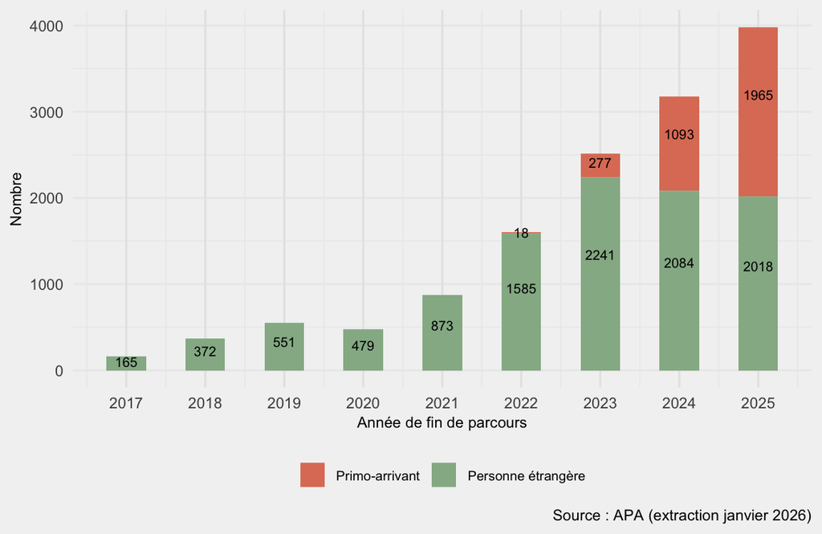

Figure 24: Évolution du nombre de parcours réalisés selon la catégorie du public (2017-2025)

Parmi les usagers·ères ayant achevé leur parcours en 2025, **34% avaient été inscrit·es la même année**. Ce taux marque une nouvelle baisse par rapport à 2024. Pour rappel l’année 2023 avait enregistré un pic historique de 50%, taux le plus élevé depuis le début de la politique. Comparé aux années pré-pandémie ce taux reste toutefois supérieur. Pour comprendre ces évolutions et plus précisément le rythme de sortie, il est indispensable d’analyser les durées de parcours.

### 5.3.2 Les durées du Parcours d’accueil

En considérant le temps de parcours des usagers·ères ayant réalisé leur parcours en 2025 (n=3.523), incluant les périodes de suspension[^65] mais **excluant les réactivations**, la durée moyenne est de 12 mois, tandis que **la durée médiane — plus pertinente au vu de certaines valeurs extrêmes (et aberrantes) — est de** **9 mois**. **Cette dernière reste identique par rapport à 2024, et la moyenne diminue de 3 mois**. Cette diminution peut notamment s’expliquer par la sortie l’année dernière d’usager·ères présent·es avant les réformes de 2022 et par une plus grande concentration dans le parcours des profils avec le plus de besoins, et dont le parcours a ainsi été plus long (eg. profils alpha).

| Catégorie de bénéfiaire | Effectif (n) | Proportion (%) | Moyenne (mois) | 1er quantile - 25% (mois) | Médiane - 50% (mois) | 3éme quantile - 75% (mois) |
| --- | --- | --- | --- | --- | --- | --- |
| Primo-arrivant obligé | 1906 | 54 | 12 | 5 | 11 | 18 |
| Personne étrangère | 1622 | 46 | 13 | 2 | 7 | 17 |

Source : APA (extraction janvier 2026)

Table 5: Distribution de la durée des parcours clôturés en 2025 selon la catégorie d’usager·ères

Ce constat n’est pas surprenant lorsque l’on considère que **les personnes primo-arrivantes présentent généralement des besoins sociaux et linguistiques plus importants que les personnes étrangères**. Toutefois, les durées moyennes de parcours révèlent une dynamique inverse : les personnes étrangères affichent des durées moyennes supérieures d’environ un mois à celles des primo-arrivant·es, et présentent une forte dispersion des temps de parcours. Leur durée moyenne est près de deux fois supérieure à leur durée médiane. Cela traduit une **plus grande hétérogénéité des situations au sein de ce public**, avec des parcours à la fois très courts et très longs. En effet, si une partie des personnes étrangères s’inscrit principalement dans le cadre d’une demande de nationalité et ne suit que la formation citoyenne, une **autre partie présente des besoins importants**, notamment en matière d’apprentissage linguistique, ce qui allonge significativement la durée de leur parcours. Par ailleurs, il convient de souligner qu’un quart du public obligé ayant terminé son parcours en 2025 a mis 18 mois ou plus pour le finaliser.

Ce dernier constat peut être illustré par les durées de parcours selon les besoins et filières linguistiques. Toutefois, afin d’élargir l’échantillon et d’éviter une surreprésentation des profils progressant le plus rapidement — notamment les usager·ères qui ont déjà atteint le niveau linguistique requis — nous avons calculé les durées moyennes et médianes de parcours sur les usager·ères ayant fini sur les 3 dernières années.

On remarque ainsi que **la durée médiane des usager·ères qui suivent une formation linguistique (18 mois) est en effet nettement plus élevée que pour celleux avec le niveau de langue requis (A2) au moment de l’inscription (5 mois)**. Parmi celleux qui suivent une formation linguistique, on observe également des variations dans la durée de parcours selon la filière linguistique :

- Les profils “Alpha” : 23 mois ;
- Les profils “FLE A” : 18 mois ;
- Les profils “FLE B” : 16 mois.

Ainsi, **si la durée médiane des filières FLE s’approche de la durée maximale du parcours, celle de la filière d’alphabétisation la dépasse même de plus de 5 mois**.

| Filière linguistique | Effectif (n) | Propotion (%) | Médiane (mois) | Moyenne (mois) |
| --- | --- | --- | --- | --- |
| ALPHA | 634 | 7 | 23 | 31 |
| FLE A (+ FLE NAL) | 906 | 10 | 18 | 25 |
| FLE B | 1001 | 11 | 16 | 18 |
| Niveau requis | 6318 | 71 | 5 | 8 |

Source : APA (extraction janvier 2026)

### 5.3.3 Les parcours d’accueil interrompus ou non achevés

Tous les dossiers clôturés ne le sont pas à la suite de la réalisation complète du parcours d’accueil. Les motifs de clôture, autre qu’avec une attestation de réalisation, diffèrent toutefois selon qu’il s’agit de primo-arrivant·es ou de personnes étrangères.

Parmi l**es clôtures sans réalisation du parcours**, **20% concernent des primo-arrivant·es**, soit 257 personnes. Bien que ces personnes soient tenues de suivre le parcours, une clôture sans réalisation n’implique pas nécessairement de sanction. Les motifs observés sont :

- 41% pour des déménagements vers une autre région ou hors de Belgique ;
- 25% pour des transferts vers BON (64) ;
- 12% liés à la volonté d’arrêter le parcours (potentiellement sanctionnable) ;
- 22% pour d’autres raisons.

Les personnes étrangères sont quant à elles plus nombreuses à voir leur dossier clôturé sans réalisation du parcours. Les principaux motifs sont :

- 33% pour absence de nouvelles ou pour perte d’intérêt pour le parcours (potentiels abandons) ;
- 17% pour non-respect des engagements prévus dans la convention d’accueil ;
- 16% pour une suspension de plus de 6 mois (clôture automatique) ;
- 34% pour d’autres raisons[^66] (dont des orientations vers des cours de langues en dehors du parcours d’accueil).

Comme indiqué précédemment dans ce monitoring, **les clôtures sans réalisation contribuent à libérer des places dans le dispositif.** Toutefois, elles ne correspondent pas toujours à des sorties définitives. C’est particulièrement le cas des personnes étrangères, pour lesquelles une part importante de ces clôtures s’apparente d’avantage à une interruption de parcours qu’à un abandon définitif. Ces personnes sont en effet susceptibles de réintégrer le dispositif ultérieurement. A l’inverse, les motifs de clôture de dossiers observés chez les primo-arrivant·es correspondent plus souvent à des véritables sortie de parcours (déménagement, transfert vers BON), même si ces situations restent relativement peu nombreuses. Dès lors, une augmentation de la part des primo-arrivant·es au sein du public accueilli pourrait mécaniquement réduire la proportion d’interruptions temporaires observées dans le dispositif.

# 6 CONCLUSION

Les constats formulés dans le rapport de Monitoring précédent restent largement d’actualité. Le Parcours d’accueil connaît une saturation généralisée depuis septembre 2024. Alors que le nombre moyen de dossiers actifs continue d’augmenter d’année en année, le nombre de nouvelles inscriptions diminue. Cette évolution ne traduit pas une baisse de la demande, mais résulte de la saturation des Bapas et de la mise en place de listes d’attente. En effet, le nombre de personnes inscrites sur celles-ci a plus que doublé en un an.

Par ailleurs, le nombre de suspensions continue d’augmenter générant une charge administrative supplémentaire pour les équipes, qui doivent alors procéder à de nombreux échanges avec les administrations communales. Ce constat, déjà formulé lors du précédent monitoring, ne montre pas d’amélioration significative, même si l’administration continue de former les équipes des communes. Cette situation est renforcée par les dysfonctionnements importants de la plateforme APA observés en 2025, ainsi que leurs conséquences sur le travail des intervenant·es (alourdissement des tâches administratives, production d’attestations, etc.). Le temps effectivement consacré à l’accompagnement social se voit réduit, fragilisant ainsi cette composante du Parcours d’accueil.

Dans ce contexte, les Bureaux d’accueil sont soumis à une pression croissante. Le report de charge d’une année à l’autre, et celui qui est cumulé, combiné au rythme des nouvelles entrées, ne permet ni de stabiliser le dispositif ni de réduire les listes d’attente. Dans ce sens, la composante la plus en tension est la formation citoyenne. Malgré l’augmentation du nombre de formations citoyennes cette année compte tenu du budget actuellement alloué pour celles-ci, **le nombre de FOCIs annuelles reste insuffisantes pour désengorger le dispositif ou faire significativement baisser les listes d’attente.** Les tendances qui se dégagent à la fin de l’année 2025 laissent même entrevoir une extension de cette saturation aux publics prioritaires à court terme.

Parallèlement, une proportion importante des usager·ères reste en demande réelle de formations linguistiques, et ce, alors que certaines filières linguistiques sont saturées (la filière d’alphabétisation notamment), ce qui a des conséquences sur les temps d’attentes aux modules et plus largement sur la durée de leur Parcours d’accueil.

En ce qui concerne les profils des usager·ères, ces derniers demeurent globalement similaires à ceux observés les années précédentes. Pour rappel, les réformes de 2022 ont accentué la diversification des publics, entre des usager·ères disposant de niveaux socio-économiques et linguistiques relativement élevés, et des usager·ères en situation de grande précarité nécessitant un accompagnement plus soutenu.

Enfin, plusieurs évolutions réglementaires et politiques devront être suivies avec attention en raison de leurs effets potentiels sur le Parcours d’accueil. Parmi celles-ci figurent l’augmentation significative des frais liés à l’acquisition de la nationalité belge, le durcissement des conditions du regroupement familial, le projet de loi visant à conditionner davantage le revenu d’intégration aux efforts d’intégration, ainsi que le retour potentiel des bénéficiaires de la protection ukrainien·nes temporaire dans le dispositif. Il sera essentiel de continuer à suivre les effets de ces réformes sur les flux d’usager·ères et sur les capacités d’absorption du dispositif.

## Footnotes

[^1]: Depuis l’entrée en vigueur de l’obligation de suivi du parcours (juin 2022), l’APA interagit directement avec l’application BruWelcome développée par la COCOM et gérée par les communes en vue de suivre les primo-arrivant·es soumis·es à l’obligation.
[^2]: Avant l’obligation, d’autres dispositifs instrumentalisaient déjà le Parcours d’accueil, comme condition à remplir pour maintenir ou obtenir des droits (renouvellement du titre de séjour, obtention de la nationalité, les CPAS et le PIIS). Pour plus de détails voir le rapport de recherche du CBAI, « *L’impact du parcours d’accueil dans l’installation des personnes migrantes à Bruxelles »*, 2021, pp.11-37.
[^3]: Pour plus de détails voir le Rapport de recherche 2025 du CBAI : « *Mesurer et suivre la politique d’accueil : analyse de la production, l’utilisation et la diffusion des données administratives du Parcours d’accueil* », pp. 34-43.
[^4]: CBAI (2025), Rapport Monitoring 2024, p. 3 (https://cbai-cracs.github.io/monitoring-2024/)
[^5]: Les autres critères sont : le caractère temporaire du séjour (moins d’un an), la fonction de diplomate, le fait d’avoir séjourné légalement et durablement au sein d’un pays de l’UE27+ (et avoir rempli les conditions d’intégration), le fait de composer un ménage avec un·e ressortissant·e de l’UE27+, la reconnaissance d’une maladie ou d’un handicap, la possession d’un autre certificat d’intégration, l’inscription précédente dans une autre commune/région où a été dispensé de Parcours d’accueil, et la reconnaissance d’un certificat d’études organisé par une des trois Communautés belges.
[^6]: Cf. Contexte institutionnel du rapport monitoring de 2024, p. 5, CBAI (2025) et “*L’obligation dans un contexte d’élargissement du Public du Parcours d’accueil. Analyse d’une transition*.” Rapport de recherche de 2024, CBAI.
[^7]: Voir le Rapport de recherche 2025 du CBAI : « *Mesurer et suivre la politique d’accueil : analyse de la production, l’utilisation et la diffusion des données administratives du Parcours d’accueil* »
[^8]: Dans le cadre de ce monitoring, nous n’avons pas trouvé nécessaire de faire une demande plus spécifique à l’échelle de la RBC. Le cas de la Belgique illustre en effet en premier lieu la situation bruxelloise.
[^9]: Selon les données de l’IBSA au 1<sup>er</sup> janvier 2025. Ici une personne étrangère est définie comme une personne n’ayant pas la nationalité belge au 01/01/2025 tout âge confondu.
[^10]: Juridiquement, il serait plus exact de parler de cartes et de documents de séjour, car aucun « titre de séjour » n’est délivré aux citoyen·nes de l’UE. Par facilité de langage, le terme « titre de séjour » est utilisé par Myria pour désigner à la fois les citoyen·nes de l’UE et les citoyen·nes non-européen·nes.
[^11]: Cf. Beauvois, J. (2026, 15 janvier). *Baisse des demandes d’asile en Belgique : résultat de la politique de l’Arizona comme le prétend la ministre Van Bossuyt ? - RTBF Actus*. RTBF. https://www.rtbf.be/article/diminution-des-demandes-d-asile-en-belgique-resultat-de-la-politique-de-l-arizona-ou-de-la-situation-internationale-11662050
[^12]: Pour plus d’information : https://emnbelgium.be/fr/nouvelles/la-belgique-enregistre-moins-de-demandes-de-protection-internationale-en-2025-tandis-que
[^13]: Cette mesure a toutefois été suspendue en urgence le 27 mars 2026 à la suite d’un recours introduit par plusieurs associations et par l’Ordre des barreaux francophones et germanophones. Les requérant·es contestaient le cadre juridique de son application et soulignaient les risques de précarisation auxquels étaient exposées les personnes concernées. Pour plus d’information : https://emnbelgium.be/fr/nouvelles/le-conseil-detat-belge-suspend-linstruction-limitant-laccueil-des-demandeurs-deja
[^14]: Au niveau européen, cette disposition est entrée en vigueur le 12 juin 2026 dans le cadre du Pacte européen sur la migration et l’asile, bien que son application dépende des transpositions nationales.
[^15]: Le quotient de localisation est un coefficient de spécificité qui se calcule par le rapport entre la proportion de PA extra-européen·nes (hors-UE27+) sur l’ensemble des PA d’une commune et cette même proportion à l’échelle régionale. Si le coefficient est supérieur à 1 alors la commune se caractérise par une présence plus importante de PA extra-européen·nes (potentiellement obligé·es) qu’en moyenne en RBC. Au contraire, s’il est inférieur à 1 celle-ci, se caractérise par une présence moindre de ce public. S’il est égal à 1, la répartition est similaire à celle de l’ensemble de la Région.
[^16]: Pour plus d’information sur cette géographie (ségrégation) résidentielle particulière, voir le Focus n°21 de l’IBSA (2017) :https://ibsa.brussels/sites/default/files/publication/documents/FOCUS-21-FR-final.pdf
[^17]: Voir l’article de G. Van Hamme, T. Grippa et M. Van Criekingen (2016). “Mouvements migratoires et dynamiques des quartiers à Bruxelles” : https://journals.openedition.org/brussels/1331#tocto1n3. Dans cet article, outre le fait que les quartiers populaires centraux (dudit “croissant pauvre”) sont des quartiers d’accueil de l’immigration internationale des pays pauvres et intermédiaires, ils montrent également que “les populations quittant les secteurs statistiques les plus pauvres de la ville s’installent en grande majorité dans les territoires intermédiaires adjacents dans l’ouest de la Région. […]. Ce processus est très certainement à l’origine de la détérioration presque généralisée des indices socio-économiques dans les secteurs statistiques socialement intermédiaires de la partie ouest de la ville. On assiste donc à un processus d’extension spatiale de la pauvreté vers l’ouest.”
[^18]: Les principaux motifs d’archivage d’un dossier sans que le parcours soit terminé sont le désintérêt pour le parcours, l’absence de reprise de contact suite à une suspension, ainsi que, dans certains cas, des archivages automatiques, notamment après des suspensions de plus de 6 mois.
[^19]: Pour mieux refléter l’évolution des publics des parcours, le public non prioritaire est distingué ici entre personnes étrangères (séjour légal de plus de trois ans) et primo-arrivant·es ayant droit soit des primo-arrivant·es exempté de l’obligation (ex. ressortissant UE) ou arrivé·es avant l’entrée en vigueur de l’obligation de suivi (juin 2022).
[^20]: Le rapport entre l’effectif du public non prioritaire en liste d’attente sur l’effectif total du public non prioritaire (en liste d’attente et en train de suivre la parcours) à cette date (31 décembre 2025).
[^21]: Le taux de surpopulation est calculé comme le rapport de la liste d’attente (1.788 personnes) sur la capacité maximale du dispositif (6.000 places), qui est également le stock de dossier actifs au 31 décembre 2025.
[^22]: Le taux d’exclusion du public non-prioritaire est calculé comme le rapport entre l’effectif en liste d’attente à la fin de l’année 2025 et l’addition de l’effectif de public non-prioritaire inscrit durant l’année 2025 et de celui de la liste d’attente à la fin de l’année 2025.
[^23]: II convient de noter qu’il s’agit d’une estimation et que les cadences peuvent varier d’un Bapa à l’autre.
[^24]: Pour une analyse approfondie des effets des réformes législatives de 2022 sur la charge de travail des Bapas, voir le Rapport de recherche 2024 du CBAI.
[^25]: La liste d’attente a été instauré à la fin de l’année 2023, afin de faire face à la saturation généralisée du dispositif, elle-même causée par les réformes législatives de 2022.
[^26]: Cf. Rapports d’activités de 2025 des Bapas.
[^27]: VIA (2026), Rapport d’activités 2025, p7.
[^28]: En raison de son déploiement en urgence, le développement informatique de la liste d’attente a été conçu avant tout comme un outil de gestion, et non un outil de suivi. Par conséquent, la collecte de données n’est pas suffisamment robuste pour fournir une représentation complète de la situation ; les données présentées représentent plutôt des ordres de grandeurs. Pour plus de détails, voir le Rapport de recherche 2025 du CBAI : “*Mesurer et suivre la politique d’accueil : analyse de la production, l’utilisation et la diffusion des données administratives du Parcours d’accueil.”,* pp.42 et pp. 86-88.
[^29]: BAPA-BXL (2026), Rapport d’activités 2025, p.21, Convivial (2026) Rapport d’activités 2025, p.4.
[^30]: Les suspensions des personnes étrangères représentent une charge de travail beaucoup moins importante, dans la mesure où relèvent d’un processus interne et ne nécessitent pas de validation par les administrations communales.
[^31]: VIA (2026), Rapport d’activités 2025, pp.21-22, Convivial (2026), Rapport d’activités 2025, p.17 et BAPA-BXL (2026), Rapport d’activités 2025, pp.23-24.
[^32]: Pour plus de détails, voir “Mesurer et suivre la politique d’accueil : analyse de la production, l’utilisation et la diffusion des données administratives du Parcours d’accueil”, pp. 34-43.
[^33]: Convivial (2026), Rapport d’activités 2025, p.17; VIA (2026), Rapport d’activités 2025, p. 22 et BAPA-BXL (2026), Rapport d’activités 2025, p. 18
[^34]: Pour rappel, une personne inscrite dans le parcours est une personne qui répond aux critères pour effectuer le parcours, et dont le Bapas accepte de prendre en charge.
[^35]: *Le bilan social “est effectué à partir des informations communiquées par le bénéficiaire, notamment, à propos de sa situation familiale, professionnelle, socio-économique, relationnelle, de formation, de santé, de handicap et de ses conditions de logement.” (Art12, Arrêté COCOM 2024)*
[^36]: Cf. “*L’obligation dans un contexte d’élargissement du public du Parcours d’accueil. Analyse d’une transition.*”, Rapport de recherche 2024, CBAI.
[^37]: Il y a 9 usager·ères pour lesquel·les le genre est inconnu soit 0,2 % du public. BAPA-BXL indique recevoir des personnes dont le genre renseigné dans les documents d’identités ne correspond pas à l’identification de la personne du fait de la difficulté à les modifier officielement (Rapport d’activité 2025, BAPA-BXL, p. 14).
[^38]: Comme dit précédemment, nous excluons ici les usager·ères qui n’ont pas encore fait le bilan social et pour qui l’information n’a pas encore été receuillie.
[^39]: Les bénéficiaires du RIS sont parfois amenées à s’inscrire au Parcours d’accueil sous la contrainte du CPAS pour pouvoir maintenir ou percevoir le revenu.
[^40]: Convivial (2026), Rapport d’activités 2025 p.12-13 ; VIA (2026), Rapport d’activités 2025, p. 7 et BAPA-BXL (2026) Rapport d’activités 2025, p.17.
[^41]: Si le Parcours d’accueil est désormais reconnu au titre du congé éducation payé, permettant aux primo-arrivant·es de suivre les formations tout en conservant leur salaire, ce dispositif reste peu mobilisé, en raison de la précarité de l’emploi, du statut d’indépendant·e ou encore de la crainte d’en faire la demande à l’employeur (notamment lors d’engagements récents).
[^42]: VIA (2026), Rapport d’activités 2025, p.17 et Convivial (2026) Rapport d’activités 2025, p 13.
[^43]: Convivial (2026), Rapport d’activités 2025, p. 13.
[^44]: Défini comme les personnes sans diplôme insuffisant pour répondre aux exigences du marché de l’emploi, on considère ici les personnes : sans diplômes, diplômées de l’enseignement primaire ou du secondaire inférieur.
[^45]: VIA (2026), Rapport d’activité 2025, p.5
[^46]: Les séjours limités concernent les cartes A, orange et les annexes 15, 19 et 19ter. Les séjours illimités (5 ans) concernent les cartes B, C, D, E, E+, F, F+.
[^47]: Le permis B est lié à un contrat de travail, les primo-arrivant·es qui en sont titulaires sont de fait exempté·es de l’obligation.
[^48]: Avant les réformes de 2022**,** Evere orientait systémiquement les personnes devant renouveler leur séjour vers les Bapas, sans que cela ne corresponde au flux réel de primo-arrivant·es.
[^49]: Le BL est effectué par les assistant·es sociaux·ales des Bapas si le choix de la langue d’apprentissage est le français et par la Huis van het Nederlands si le choix est le néerlandais.
[^50]: Dans la première version publiée de ce rapport de monitoring, les modules de DD de Convivial n’avaient pas été pris en compte en raison d’une erreur.
[^51]: Ici on considère les modules arabes : les modules d’arabe (non spécifié), arabe oriental (19 %), d’arabe maghrébin (19%).
[^52]: VIA (2026), Rapport d’activités 2025, p. 42.
[^53]: Cf. Rapport de recherche de 2024 du CBAI : *« L’obligation de suivi dans un contexte d’élargissement du public. Analyse d’une transition »*, pp. 75-88.
[^54]: BAPA-BXL (2026), Rapport d’activités 2025, p. 47.
[^55]: Convivial (2026), Rapport d’activités 2025, p. 29.
[^56]: Ibid.
[^57]: VIA (2026), Rapport d’activités 2025 p.41.
[^58]: Le maintien de ce taux de participation repose sur le travail systématique de confirmation des présences, réalisé entre 5 et 10 jours avant le début des formations. Ce suivi permet d’optimiser l’occupation des places disponibles, devenu très important depuis la saturation, mais génère une charge de travail conséquente pour les équipes.
[^59]: En ne distinguant pas les différentes formes de l’arabe (classique, maghrébin, oriental, oriental alpha).
[^60]: Ces modules sont destinés aux personnes non-natives présentant un niveau intermédiaire ou débutant en anglais. BAPA-BXL (2026), Rapport d’activité 2025, p.40
[^61]: CF. Rapport Monitoring 2024, CBAI, p 50 (https://cbai-cracs.github.io/monitoring-2024/)
[^62]: Données présentées par la COCOF lors de la réunion annuelle Bapas-OLs-COCOF-COCOM le 27 mai 2026.
[^63]: Ici, une inscription ne concerne pas une personne mais le fait de s’inscrire à un module. Une personne peut donc être comptée plusieurs fois si elle a suivi plusieurs modules.
[^64]: VIA (2026), Rapport d’activités 2025, p. 28.
[^65]: Un problème technique lié à l’évolution de l’Application Primo-arrivant nous empêche de calculer les périodes de suspension, et donc de les soustraire à la durée de parcours totale.
[^66]: Le taux élevé de la catégorie “autres raisons”, s’explique par l’encodage des motifs dans des champs ouverts de la plateforme lorsqu’ils ne correspondent à aucune option de la liste déroulante. Pour des raisons de protection des données (RGPD), le contenu de ces champs n’est pas accessible et est dès lors regroupé sous cette catégorie.